# Geospatial Analysis of the 2020 California Wildfires: Environmental Determinants and Implications

Final Project - Geospatial Data Science 🌍

Irache Vergara, Gretchen Moulton, Viktoria Gagua, Daniela Guggenberger

March 23, 2025

# 1 Introduction

Wildfires have long been a part of California’s landscape, but 2020 marked a record-breaking year, with fires burning millions of acres and causing severe damage to communities, ecosystems, and infrastructure (UC Davis Report 2022).

The increasing frequency and severity of wildfires raise important questions about the factors driving these events. Understanding the key factors that contribute to wildfires is essential not only for improving prevention and mitigation strategies but also for assessing their broader economic, environmental, and political implications.

This project focuses on the spatial determinants of wildfires in California during 2020, using geospatial analysis to explore how drought severity, vegetation, topography, and proximity to human activity influence fire behavior. Specifically, we investigate:

- Temperature: How one aspect of weather conditions contribute to fire intensity and spread.
- Water availability and drought conditions (SPEI): The impact of humidity and water availability on fire patterns.
- Elevation: How slope influences fire behavior and distribution.
- Proximity to populated areas: The role of urban development in fire ignition and spread.
- Land Cover Type: What role does land cover play in determining fire patterns and distribution?

Beyond physical drivers, wildfires have far-reaching economic, environmental, and policy implications, including air quality degradation, public health risks, and land management debates. By identifying spatial patterns and correlations, this study seeks to improve understanding of wildfire risks and support more effective mitigation strategies and adaptation solutions.

Our analysis relies on a combination of satellite imagery, environmental monitoring data, and official records to map fire patterns and assess correlations between different factors. Through this research, we aim to highlight key insights that can help policymakers, researchers, and communities better understand and manage wildfire risks.

# 2 Data Exploration

First to analysis wildfires in California in 2020, we gather fire perimeter data from the Fire and Resource Assessment Program (FRAP) from California Department of Forestry and Fire Protection. Using this vector data, we can see the outline of each fire and the area burned. We load the cleaned data (cleaning shown in Appendix) that we previously merged with data from NASA Fire Information for Resource Management System (FIRMS) in order to include information on brightness.

We also load the shape file of the United States from Natural Earth and filter on just the boundary of California. We ensure that the CRS of the wildfire data and the shape of California are the same. Lastly, we simplify the fire data by reducing the detail of geometries using a tolerance of 20 meters to make computations faster.

```r
# We will load our data containing spatial data for wildfires in 2020
url <- "/vsicurl/https://raw.githubusercontent.com/Viktoriag27/Geospatial_Cali_Wildfires/main/merged_fires_cleaned.gpkg"
fire_data <- st_read(url)
# We need to get the California Border shape file by getting US States
url <- "/vsicurl/https://github.com/Viktoriag27/Geospatial_Cali_Wildfires/raw/main/CA_Outline/ne_110m_admin_1_states_provinces/ne_110m_admin_1_states_provinces.shp"
US_States <- st_read(url)
# too many columns to work with, we will select fewer
US_States_simple <- US_States %>% dplyr::select(name, postal, latitude, longitude, geometry)
# select just CA
california_boundary <- US_States_simple %>% filter(postal=="CA")

# Convert fire data to match California CRS
fire_data <- st_transform(fire_data, crs = st_crs(california_boundary))
fire_data <- st_make_valid(fire_data)
#simplify using 20 meters to make computations a bit quicker
fire_data<- st_simplify(fire_data, dTolerance = 20)
```

We plot the shape of California and the fire data to see where fires occurred throughout the state in 2020. Fires occurred across the entire state, with large fires tending to occur in the northern region.

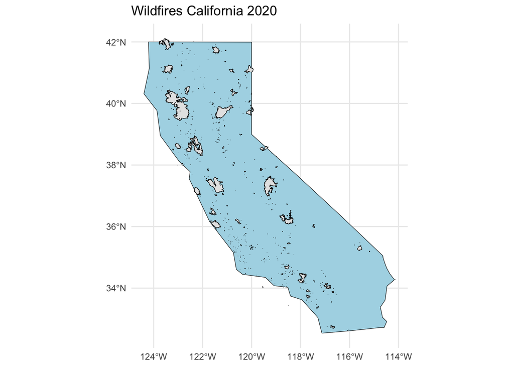

```r
#Let's see what this looks like
ggplot()+
 geom_sf(data=california_boundary, fill="lightblue", color = "black")+
 geom_sf(data=fire_data, color = "black") +
  ggtitle("Wildfires California 2020") +
  theme_minimal()
```

# 3 Key Variables

## 3.1 Fire Duration (Days)

- Duration (days): Measures how long a wildfire burns.

We calculated this variable before adding it to our cleaned data by taking the difference between the date the fire started and the date the fire was contained and adding 1, so fires beginning and ending on the same day were not 0. The shortest fires lasted only 1 day and the longest fire lasted for 183 days. We can see the variation plotted above.

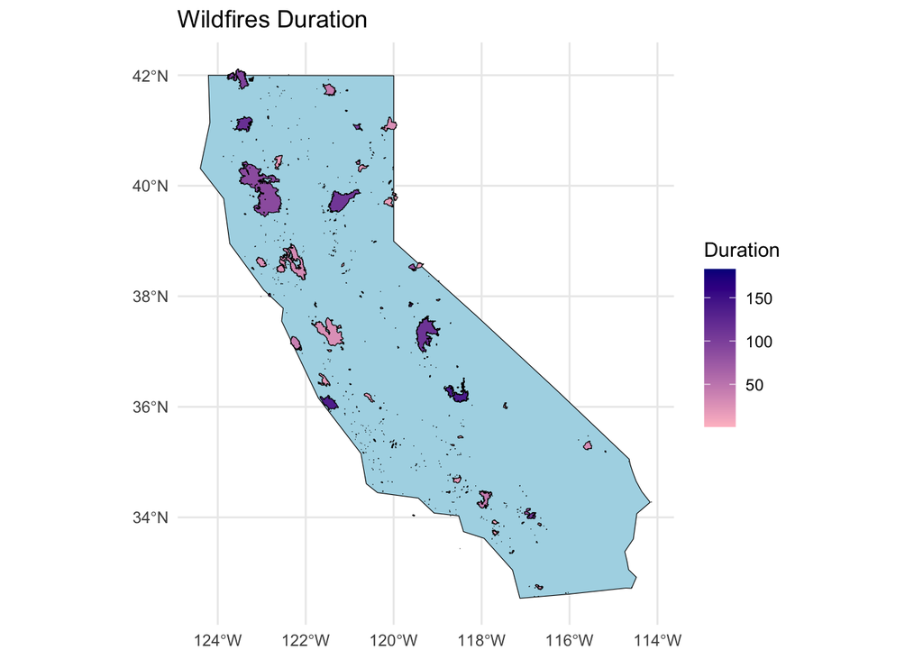

```r
#fill scale is number of days each fire lasted
ggplot()+
  geom_sf(data=california_boundary, fill="lightblue", color = "black")+
  geom_sf(data=fire_data, aes(fill = duration), color = "black") +
  scale_fill_gradient(name = "Duration", low = "pink", high = "darkblue")  +
  ggtitle("Wildfires Duration")+
  theme_minimal()
```

There are 11 fires that have NAs for `CONT_DATE`, making their duration NA. We remove these observations, as it is an instance of missing data. Our data contains other observations of fires contained outside of 2020 (in 2021) so these NAs are not an issue of containment occurring outside of the calendar year.

```r
# Count how many rows have a missing duration
missing <- fire_data[is.na(fire_data$duration), ]
nrow(missing) # changed count(missing)
```

```
## [1] 11
```

```r
# Remove rows where duration is NA
fire_data <- fire_data[!is.na(fire_data$duration), ]
```

## 3.2 Fire Brightness (Kelvin)

- Brightness (Kelvin): Captured from satellite Channel 21/22, indicating fire intensity.

We can see there is very little variation in the average brightness of each fire. The range of brightness of the fires is 301 K to 401 K.

Many of our fires do not contain brightness data (384). We will store a new dataframe `fire_data_brightness` with only the observations that contain brightness (110).

```r
#fill using the average brightness of fires
#count how many missing
missing <- fire_data[is.na(fire_data$avg_brightness), ]

nrow(missing)
```

```
## [1] 384
```

```r
#there are 384 observations that do not contain brightness data. We will store a new data frame with just the observations containing brightness

fire_data_brightness <- fire_data %>%
  filter(!is.na(avg_brightness))
nrow(fire_data_brightness)
```

```
## [1] 110
```

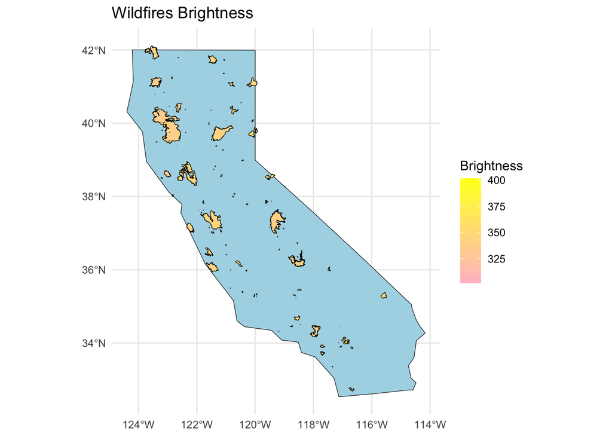

```r
ggplot()+
  geom_sf(data=california_boundary, fill="lightblue", color = "black")+
  geom_sf(data=fire_data_brightness, aes(fill = avg_brightness), color = "black") +
  scale_fill_gradient(name = "Brightness", low = "pink", high = "yellow")+
  ggtitle("Wildfires Brightness")+
  theme_minimal()
```

## 3.3 Fire Size (Acres)

- Acreage (acres): Represents the total land area burned.

Each fire contains data of the size of the fire in acres. There is no missing data for this variable. The fires in this data set ranged from 1 acre to 1,032,700 acres.

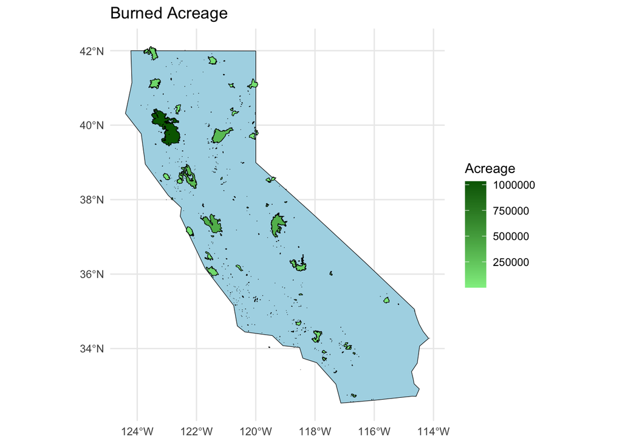

```r
#fill by size of fire
ggplot()+
  geom_sf(data=california_boundary, fill="lightblue", color = "black")+
  geom_sf(data=fire_data, aes(fill = GIS_ACRES), color = "black") +
  scale_fill_gradient(name = "Acreage", low = "lightgreen", high = "darkgreen")+
  ggtitle("Burned Acreage")+
  theme_minimal()
```

# 4 Relationship of Temperature and Fire Intensity

In this part we investigate the role of weather conditions, specifically air temperature on the intensity of fires.

The US National Oceanic and Atmosphere Administration (NOAA) explains that climate change has lead to an increase in wildfires. More carbon emissions have led to an increase in weather shocks, such as droughts, and an overall warmer climate, creating hotter and drier conditions that are more prone to fire. To evaluate the impact of a warming planet on wildfires, we would need to evaluate year over year trends. However, we can also investigate the role of short term variations in the weather and to see their impact on wildfires.

One way to do this is to look at fluctuation in temperature throughout one year. We gathered GeoTIFF files detailing daily maximum temperatures (tmax) measured in Celsius across the United States from NOAA. Rather than look at raster data from 365 different days in 2020, which computationally was challenging due to the size of the GeoTIFF images, we chose to look at the 15th of each month to identify annual cyclical trends in temperature. We chose to work with this data as it was the most detailed and showed variation throughout California. When we looked at monthly averages, the national level data was not detailed enough and showed very little variation at the state level on average. We opted to prioritize detailed data to better visualize on a map the association between temperature and wildfire occurrences.

We recognize this approach has significant limitations. An ideal analysis of shocks in temperature would gather data for each day of 2020 to see better see extremes. The best way to study trends in temperature would be to look at monthly averages across decades. However, due to data limitations neither of these approaches were feasible. We note that in the future we could enhance the project by looking at daily or monthly average or max temperatures.

## 4.1 Data Preparation

To begin our analysis, we first need to identify which fires occurred in which months. To organize the data we will create 12 binary variables, 1 for each month, that designate if the fire occurred during that month.

```r
#create binary variables for each month containing 1 if a fire occurred in that month, 0 if not
fire_data <- fire_data %>%
  mutate(
    Jan = ifelse(between(month(ALARM_DATE), 1, 1) | between(month(CONT_DATE), 1, 1), 1, 0),
    Feb = ifelse(between(month(ALARM_DATE), 2, 2) | between(month(CONT_DATE), 2, 2), 1, 0),
    Mar = ifelse(between(month(ALARM_DATE), 3, 3) | between(month(CONT_DATE), 3, 3), 1, 0),
    Apr = ifelse(between(month(ALARM_DATE), 4, 4) | between(month(CONT_DATE), 4, 4), 1, 0),
    May = ifelse(between(month(ALARM_DATE), 5, 5) | between(month(CONT_DATE), 5, 5), 1, 0),
    Jun = ifelse(between(month(ALARM_DATE), 6, 6) | between(month(CONT_DATE), 6, 6), 1, 0),
    Jul = ifelse(between(month(ALARM_DATE), 7, 7) | between(month(CONT_DATE), 7, 7), 1, 0),
    Aug = ifelse(between(month(ALARM_DATE), 8, 8) | between(month(CONT_DATE), 8, 8), 1, 0),
    Sep = ifelse(between(month(ALARM_DATE), 9, 9) | between(month(CONT_DATE), 9, 9), 1, 0),
    Oct = ifelse(between(month(ALARM_DATE), 10, 10) | between(month(CONT_DATE), 10, 10), 1, 0),
    Nov = ifelse(between(month(ALARM_DATE), 11, 11) | between(month(CONT_DATE), 11, 11), 1, 0),
    Dec = ifelse(between(month(ALARM_DATE), 12, 12) | between(month(CONT_DATE), 12, 12), 1, 0)
  )
# sum to see how many fires occurred in each month
months <- c("Jan", "Feb", "Mar", "Apr", "May", "Jun", "Jul", "Aug", "Sep", "Oct", "Nov", "Dec")
monthly_sums <- sapply(months, function(month) sum(fire_data[[month]], na.rm = TRUE))
monthly_sums
```

```
## Jan Feb Mar Apr May Jun Jul Aug Sep Oct Nov Dec
##   4  11   6   6  30 109 115 134  70  41  27  23
```

From this we can see most fires occur in the summer and fall (May - November), with August being the month with the most fires in 2020.

Now we will explore to see the monthly temperatures and the fires that occurred in that month. We first load our GeoTiffs for each month. We plot the weather raster for the 15th of each month and the fires that occurred in each month.

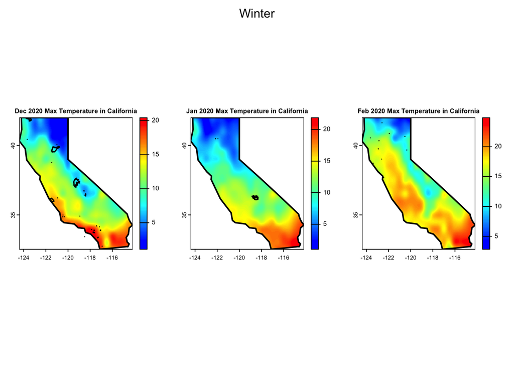

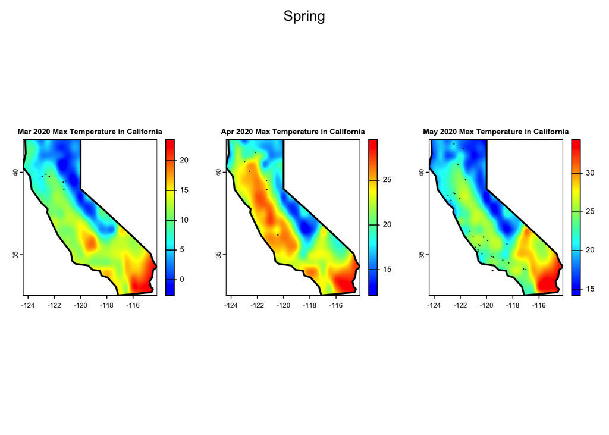

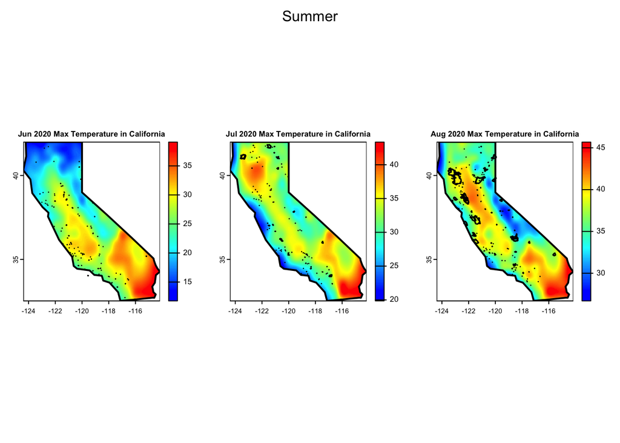

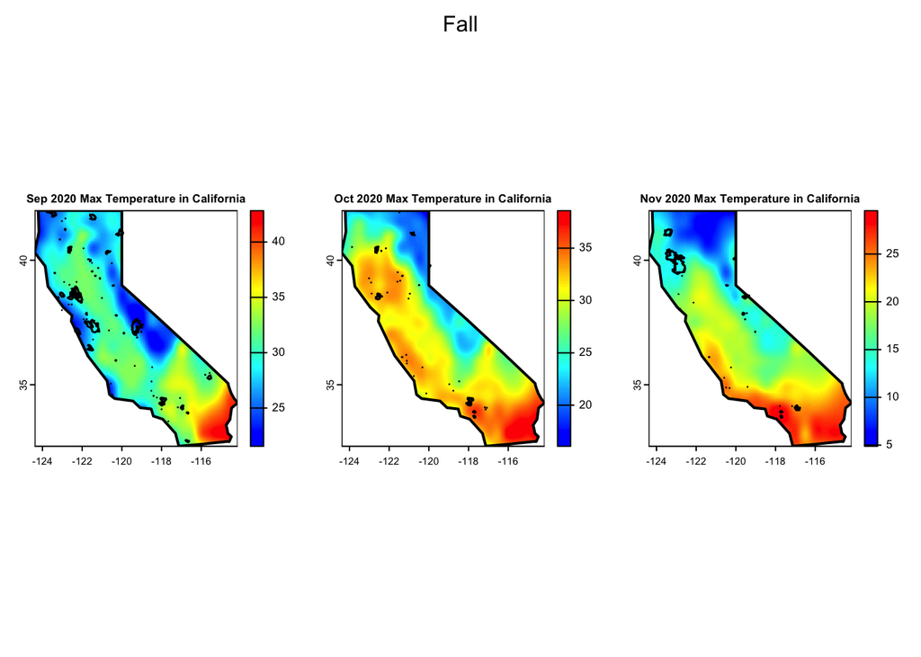

```r
# Define the base URL for the raster files in GitHub
github_base <- "/vsicurl/https://github.com/Viktoriag27/Geospatial_Cali_Wildfires/raw/main/Weather/Temperature/"

# this is our list of months
months <- c("January", "February", "March", "April", "May", "June",
            "July", "August", "September", "October", "November", "December")

# Create a named list with the updated GitHub paths
monthly_rasters <- setNames(
  paste0(github_base, months, "_2020.tif"),
  substr(months, 1, 3)
)
# gather all raster files into a list
raster_list <- lapply(monthly_rasters, rast)

# transform California shapefile to match the CRS of the rasters
california_boundary <- st_transform(california_boundary, crs = 4326)

# process rasters and crop to California shape
processed_rasters <- lapply(monthly_rasters, function(raster_path) {
  temp_raster <- rast(raster_path)
  template_raster <- rast(temp_raster)
  res(template_raster) <- 0.02
  ext(template_raster) <- ext(temp_raster)
  temp_raster_resampled <- resample(temp_raster, template_raster, method = "cubic")
  temp_raster_cropped <- crop(temp_raster_resampled, ext(california_boundary))
  california_boundary_r <- rasterize(vect(california_boundary), temp_raster_cropped, field = 1)
  mask(temp_raster_cropped, california_boundary_r)
})

# we also want to group months by season for simpler plotting
seasons <- list(
  Winter = c("Dec", "Jan", "Feb"),
  Spring = c("Mar", "Apr", "May"),
  Summer = c("Jun", "Jul", "Aug"),
  Fall = c("Sep", "Oct", "Nov")
)

# plot each season
for (season in names(seasons)) {
  par(mfrow = c(1, 3), mar = c(5, 5, 5, 1))
  for (month in seasons[[season]]) {
    temp_raster_precise <- processed_rasters[[month]]
    plot(temp_raster_precise, main = paste(month, "2020 Max Temperature in California"),
         col = colorRampPalette(c("blue", "cyan", "yellow", "red"))(100), cex.main = 0.8)
    plot(st_geometry(california_boundary), add = TRUE, border = "black", lwd = 2)

    # Overlay fire data
    if (month %in% names(fire_data) && any(fire_data[[month]] == 1, na.rm = TRUE)) {
      fires_this_month <- fire_data %>% filter(fire_data[[month]] == 1)
      if (nrow(fires_this_month) > 0) {
        fire_sf <- st_as_sf(fires_this_month, coords = c("Longitude", "Latitude"), crs = 4326)
        plot(st_geometry(fire_sf), add = TRUE, border = "black", col = NA, cex = 1.5, lwd = 1.3)
      }
    }
  }
  mtext(season, side = 3, line = -2, outer = TRUE, cex = 1)
}
```

Here we see the temperature across California on the 15th of the month and the fires that occurred in each month. From these graphs, we can easily visualize the seasonality of the fires, with more wildfires occurring in summer and fall.

Now let’s specifically investigate the average max temperature of the area of the fire. We will use extraction of the data from the rasters to conduct this step. We will use temperature data from the area of the fire from the months the fire occurred. For example, if the fire occurred only in July, we will find the average max temperature across the area where it occurred on July 15th. If the fire occurred in July and August, we will find the average max temperature in the area of the fire from July 15th and August 15th. Again, we note a limitation of this data is the fire may not have occurred on the 15th of the month. Max or average daily temperatures would better encapsulate actual temperatures when the fire occurred.

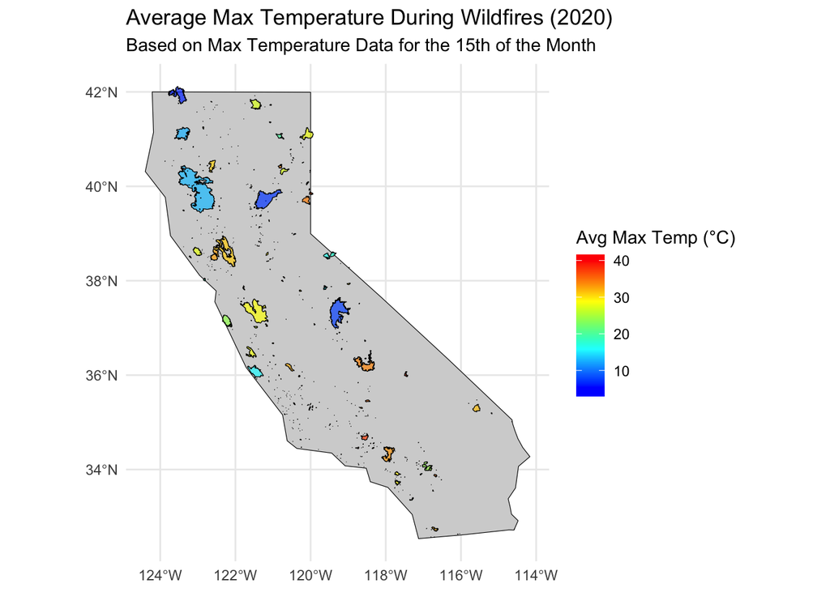

```r
# Initialize a column for average temperature in the fire dataset
fire_data$avg_temp <- NA

# loop through each month
for (month in names(processed_rasters)) {
  temp_raster <- processed_rasters[[month]]
  # Ensure fire data CRS matches raster CRS
  fire_data <- st_transform(fire_data, crs = crs(temp_raster))
  # Filter on fires that occurred in the month
  valid_indices <- which(!is.na(fire_data[[month]]) & fire_data[[month]] == 1)
  if (length(valid_indices) > 0) {
    fires_this_month <- fire_data[valid_indices, ]
    # Convert fire polygons to terra format (SpatVector)
    fire_vect <- vect(fires_this_month)
    # Extract temperature values within each fire polygon and compute the mean
    extracted_values <- terra::extract(temp_raster, fire_vect, fun = function(x) { if (all(is.na(x))) NA else mean(x, na.rm = TRUE) })
    # Check if extracted values exist
    if (!is.null(extracted_values)) {
      # Assign the extracted temperature values back to the fire dataset
      fire_data$avg_temp[valid_indices] <- extracted_values[, 2]
    } else {
      print(paste("Warning: No temperature data extracted for fires in", month))
    }
  } else {
    print(paste("No fires occurred in", month))
  }
}
# There are 8 small fires that occur outside the border of California so we drop these
fire_data <- fire_data %>%
  filter(!is.na(avg_temp))

# Plot California map with fire polygons
ggplot() +
  geom_sf(data = california_boundary, fill = "lightgrey", color = "black") +
  geom_sf(data = fire_data, aes(fill = avg_temp), color = "black", alpha = 0.7) +
  scale_fill_gradientn(colors = colorRampPalette(c("blue", "cyan", "yellow", "red"))(100), name = "Avg Max Temp (°C)" ) +
  labs(title = "Average Max Temperature During Wildfires (2020)",
       subtitle = "Based on Max Temperature Data for the 15th of the Month") +
  theme_minimal() +
  theme(legend.position = "right")
```

Here we have plotted all of the fires from 2020 filled with the average temperature on the 15th of each month they occurred during to see the differences in temperature for different fires. From here we can see that some of the larger fires do not appear be occurring during warmer temperatures, with the biggest fire having an average max temperature (outside air) of around 15 degrees.

Now we will use the average max temperature in the area of each fire we just calculated to investigate how it may influence fire intensity: the size of the fire (acreage), duration of fire (days), and the brightness of each fire (Kelvin (K).

## 4.2 Temperature and Fire Size

We will investigate the role of temperature on the size of fires. We are going to look at each season individually because the data is incredibly skewed to the right as most fires occur in the summer and fall when it is warmer. Therefore it is challenging to assess any trend when looking at the data all together.

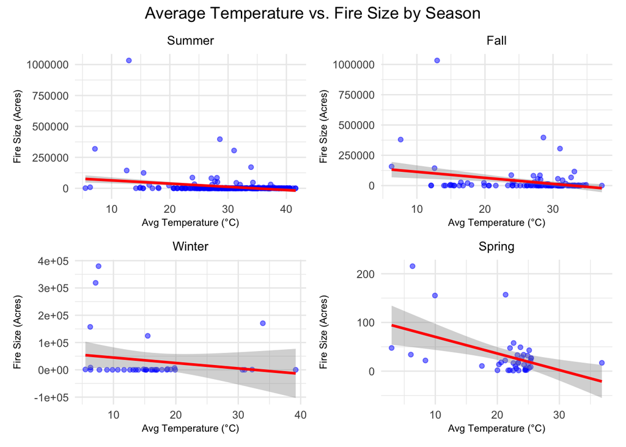

```r
#We filter to get fires occurring in each season
summer_fires <- fire_data %>%
  filter(Jun == 1 | Jul == 1 | Aug == 1)
fall_fires <- fire_data %>%
  filter(Sep == 1 | Oct == 1 | Nov == 1)
winter_fires <- fire_data %>%
  filter(Dec == 1 | Jan == 1 | Feb == 1)
spring_fires <- fire_data %>%
  filter(Mar == 1 | Apr == 1 | May == 1)

# Scatter plot for Summer Fires
plot_summer <- ggplot(summer_fires, aes(x = avg_temp, y = GIS_ACRES)) +
  geom_point(alpha = 0.5, color = "blue") +
  geom_smooth(method = "lm", color = "red") +
  labs(title = "Summer",
       x = "Avg Temperature (°C)", y = "Fire Size (Acres)") +
  theme_minimal()+
  theme(plot.title = element_text(size = 10),
  axis.title.x = element_text(size = 8),
  axis.title.y = element_text(size = 8) )

# Scatter plot for Fall Fires
plot_fall <- ggplot(fall_fires, aes(x = avg_temp, y = GIS_ACRES)) +
  geom_point(alpha = 0.5, color = "blue") +
  geom_smooth(method = "lm", color = "red") +
  labs(title = "Fall",
       x = "Avg Temperature (°C)", y = "Fire Size (Acres)") +
  theme_minimal()+
  theme(plot.title = element_text(size = 10),
  axis.title.x = element_text(size = 8),
  axis.title.y = element_text(size = 8) )

# Scatter plot for Winter Fires
plot_winter <- ggplot(winter_fires, aes(x = avg_temp, y = GIS_ACRES)) +
  geom_point(alpha = 0.5, color = "blue") +
  geom_smooth(method = "lm", color = "red") +
  labs(title = "Winter",
       x = "Avg Temperature (°C)", y = "Fire Size (Acres)") +
  theme_minimal()+
  theme(plot.title = element_text(size = 10),
  axis.title.x = element_text(size = 8),
  axis.title.y = element_text(size = 8) )

# Scatter plot for Spring Fires
plot_spring <- ggplot(spring_fires, aes(x = avg_temp, y = GIS_ACRES)) +
  geom_point(alpha = 0.5, color = "blue") +
  geom_smooth(method = "lm", color = "red") +
  labs(title = "Spring",
       x = "Avg Temperature (°C)", y = "Fire Size (Acres)") +
  theme_minimal()+
  theme(plot.title = element_text(size = 10),
  axis.title.x = element_text(size = 8),
  axis.title.y = element_text(size = 8) )

# Load patchwork library
library(patchwork)

# Combine all the plots in one row using patchwork with spacing adjustments
(plot_summer + plot_fall + plot_winter + plot_spring) +
  plot_layout(ncol = 2) +
  plot_layout(nrow = 2) +
  plot_annotation(title = "Average Temperature vs. Fire Size by Season") &
  theme(plot.title = element_text(hjust = 0.5))
```

Here we see a negative trend across all seasons. As temperatures rise, it appears fire size decreases; however, this may be largely driven by extreme outliers. We will now remove outliers from our data as most fires are less than 250,000 acres. We will also filter on fires that exceed 1,000 acres because any wildfire below 1,000 acres is classified as small. We will focus on these large and medium wildfires, as it is difficult to show trends when including extremely large or small fires.

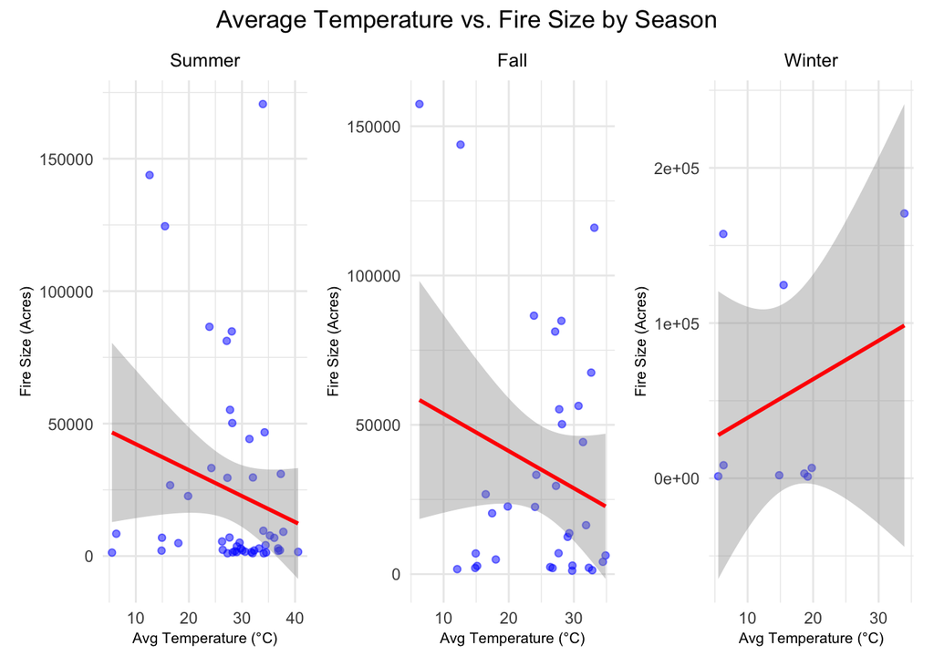

```r
# Filter the fire data to include only fires with GIS_ACRES < 300,000 acres
fire_data_filtered <- fire_data %>%
  filter(GIS_ACRES < 250000) %>%
  filter(GIS_ACRES > 1000)

summer_fires_filtered <- fire_data_filtered %>%
  filter(Jun == 1 | Jul == 1 | Aug == 1)
fall_fires_filtered <- fire_data_filtered %>%
  filter(Sep == 1 | Oct == 1 | Nov == 1)
winter_fires_filtered <- fire_data_filtered %>%
  filter(Dec == 1 | Jan == 1 | Feb == 1)
spring_fires_filtered <- fire_data_filtered %>%
  filter(Mar == 1 | Apr == 1 | May == 1)


# Scatter plot for Summer Fires
plot_summer <- ggplot(summer_fires_filtered, aes(x = avg_temp, y = GIS_ACRES)) +
  geom_point(alpha = 0.5, color = "blue") +
  geom_smooth(method = "lm", color = "red") +
  labs(title = "Summer",
       x = "Avg Temperature (°C)", y = "Fire Size (Acres)") +
  theme_minimal()+
  theme(plot.title = element_text(size = 10),
  axis.title.x = element_text(size = 8),
  axis.title.y = element_text(size = 8) )

# Scatter plot for Fall Fires
plot_fall <- ggplot(fall_fires_filtered, aes(x = avg_temp, y = GIS_ACRES)) +
  geom_point(alpha = 0.5, color = "blue") +
  geom_smooth(method = "lm", color = "red") +
  labs(title = "Fall",
       x = "Avg Temperature (°C)", y = "Fire Size (Acres)") +
  theme_minimal()+
  theme(plot.title = element_text(size = 10),
  axis.title.x = element_text(size = 8),
  axis.title.y = element_text(size = 8) )

# Scatter plot for Winter Fires
plot_winter <- ggplot(winter_fires_filtered, aes(x = avg_temp, y = GIS_ACRES)) +
  geom_point(alpha = 0.5, color = "blue") +
  geom_smooth(method = "lm", color = "red") +
  labs(title = "Winter",
       x = "Avg Temperature (°C)", y = "Fire Size (Acres)") +
  theme_minimal()+
  theme(plot.title = element_text(size = 10),
  axis.title.x = element_text(size = 8),
  axis.title.y = element_text(size = 8) )

# Load patchwork library
library(patchwork)

# Combine all the plots in one row using patchwork with spacing adjustments
(plot_summer + plot_fall + plot_winter) +
  plot_layout(ncol = 3) +
  plot_annotation(title = "Average Temperature vs. Fire Size by Season") &
  theme(plot.title = element_text(hjust = 0.5))
```

From this analysis, we notice a positive trend for wildfires in the winter, but there is a negative trend for summer and fall. There were no fires in spring that were larger than 1,000 acres so we did not include this in our analysis. It appears that during the warmer months (summer and fall), hotter temperatures are associated with smaller fires. It may be that fires are more likely to occur when its hot, so officials are more prepared to respond faster and thus the fires are put out quicker. Additional research needs to be conducted, ideally with daily temperature data or monthly averages to assess these trends.

## 4.3 Temperature and Fire Duration

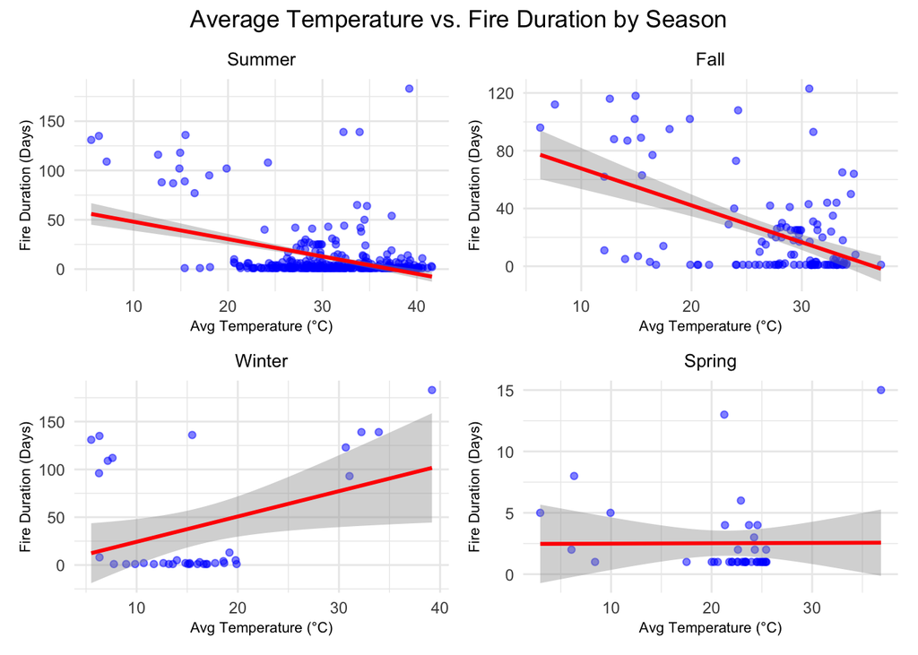

```r
# Scatter plot for Summer Fires
plot_summer <- ggplot(summer_fires, aes(x = avg_temp, y = duration)) +
  geom_point(alpha = 0.5, color = "blue") +
  geom_smooth(method = "lm", color = "red") +
  labs(title = "Summer",
       x = "Avg Temperature (°C)", y = "Fire Duration (Days)") +
  theme_minimal()+
  theme(plot.title = element_text(size = 10),
  axis.title.x = element_text(size = 8),
  axis.title.y = element_text(size = 8) )

# Scatter plot for Fall Fires
plot_fall <- ggplot(fall_fires, aes(x = avg_temp, y = duration)) +
  geom_point(alpha = 0.5, color = "blue") +
  geom_smooth(method = "lm", color = "red") +
  labs(title = "Fall",
       x = "Avg Temperature (°C)", y = "Fire Duration (Days)") +
  theme_minimal()+
  theme(plot.title = element_text(size = 10),
  axis.title.x = element_text(size = 8),
  axis.title.y = element_text(size = 8) )

# Scatter plot for Winter Fires
plot_winter <- ggplot(winter_fires, aes(x = avg_temp, y = duration)) +
  geom_point(alpha = 0.5, color = "blue") +
  geom_smooth(method = "lm", color = "red") +
  labs(title = "Winter",
       x = "Avg Temperature (°C)", y = "Fire Duration (Days)") +
  theme_minimal()+
  theme(plot.title = element_text(size = 10),
  axis.title.x = element_text(size = 8),
  axis.title.y = element_text(size = 8) )

# Scatter plot for Spring Fires
plot_spring <- ggplot(spring_fires, aes(x = avg_temp, y = duration)) +
  geom_point(alpha = 0.5, color = "blue") +
  geom_smooth(method = "lm", color = "red") +
  labs(title = "Spring",
       x = "Avg Temperature (°C)", y = "Fire Duration (Days)") +
  theme_minimal()+
  theme(plot.title = element_text(size = 10),
  axis.title.x = element_text(size = 8),
  axis.title.y = element_text(size = 8) )

# Load patchwork library
library(patchwork)

# Combine all the plots in one row using patchwork with spacing adjustments
(plot_summer + plot_fall + plot_winter + plot_spring) +
  plot_layout(ncol = 2) +
  plot_layout(nrow = 2) +
  plot_annotation(title = "Average Temperature vs. Fire Duration by Season") &
  theme(plot.title = element_text(hjust = 0.5))
```

When first looking at the plots, we can see that as temperatures rise in the summer and fall, the duration of the fire decreases; however, this may be more indicative that during hotter times, the number of small fires increases. Nevertheless, in the summer and fall, we see a negative correlation. However in winter, we see a positive trend, where hotter temperatures are associated with longer fires. In spring there is no trend.

It appears most fires are less than 50 days. We will investigate fires under 50 days to see if there are any other discernible trends once some outliers are removed.

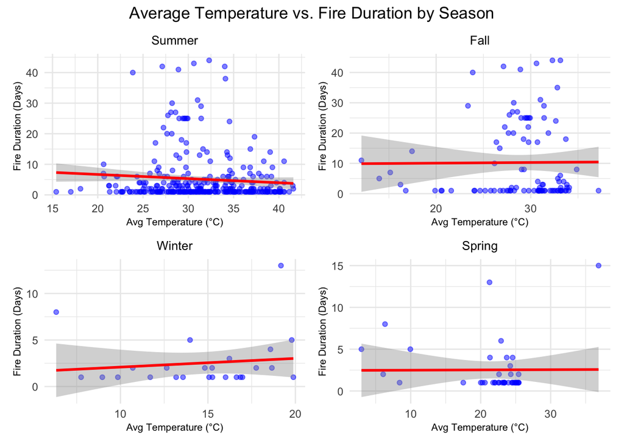

```r
# Filter the fire data to include only fires lasting less than 50 days
fire_data_under_50days <- fire_data %>%
  filter(duration < 50)

summer_fires_50days <- fire_data_under_50days %>%
  filter(Jun == 1 | Jul == 1 | Aug == 1)
fall_fires_50days <- fire_data_under_50days %>%
  filter(Sep == 1 | Oct == 1 | Nov == 1)
winter_fires_50days <- fire_data_under_50days %>%
  filter(Dec == 1 | Jan == 1 | Feb == 1)
spring_fires_50days <- fire_data_under_50days %>%
  filter(Mar == 1 | Apr == 1 | May == 1)


# Scatter plot for Summer Fires
plot_summer <- ggplot(summer_fires_50days, aes(x = avg_temp, y = duration)) +
  geom_point(alpha = 0.5, color = "blue") +
  geom_smooth(method = "lm", color = "red") +
  labs(title = "Summer",
       x = "Avg Temperature (°C)", y = "Fire Duration (Days)") +
  theme_minimal()+
  theme(plot.title = element_text(size = 10),
  axis.title.x = element_text(size = 8),
  axis.title.y = element_text(size = 8) )

# Scatter plot for Fall Fires
plot_fall <- ggplot(fall_fires_50days, aes(x = avg_temp, y = duration)) +
  geom_point(alpha = 0.5, color = "blue") +
  geom_smooth(method = "lm", color = "red") +
  labs(title = "Fall",
       x = "Avg Temperature (°C)", y = "Fire Duration (Days)") +
  theme_minimal()+
  theme(plot.title = element_text(size = 10),
  axis.title.x = element_text(size = 8),
  axis.title.y = element_text(size = 8) )

# Scatter plot for Winter Fires
plot_winter <- ggplot(winter_fires_50days, aes(x = avg_temp, y = duration)) +
  geom_point(alpha = 0.5, color = "blue") +
  geom_smooth(method = "lm", color = "red") +
  labs(title = "Winter",
       x = "Avg Temperature (°C)", y = "Fire Duration (Days)") +
  theme_minimal()+
  theme(plot.title = element_text(size = 10),
  axis.title.x = element_text(size = 8),
  axis.title.y = element_text(size = 8) )

# Scatter plot for Spring Fires
plot_spring <- ggplot(spring_fires_50days, aes(x = avg_temp, y = duration)) +
  geom_point(alpha = 0.5, color = "blue") +
  geom_smooth(method = "lm", color = "red") +
  labs(title = "Spring",
       x = "Avg Temperature (°C)", y = "Fire Duration (Days)") +
  theme_minimal()+
  theme(plot.title = element_text(size = 10),
  axis.title.x = element_text(size = 8),
  axis.title.y = element_text(size = 8) )

# Load patchwork library
library(patchwork)

# Combine all the plots in one row using patchwork with spacing adjustments
(plot_summer + plot_fall + plot_winter + plot_spring) +
  plot_layout(ncol = 2) +
  plot_layout(nrow = 2) +
  plot_annotation(title = "Average Temperature vs. Fire Duration by Season") &
  theme(plot.title = element_text(hjust = 0.5))
```

Once we remove fires that have a duration over 50 days, we see that the plots for summer and fall change drastically, with fall having no correlation and summer still has a negative trend but less steep. Spring still has no discernible trend and the positive trend in winter also became drastically less steep.

There are no clear trends from this analysis once we removed outliers. It appears that temperature may not play a key role in the duration of a fire in our data.

## 4.4 Temperature and Fire Brightness

We will now analyze to see if there is any correlation between temperature and brightness of fires.

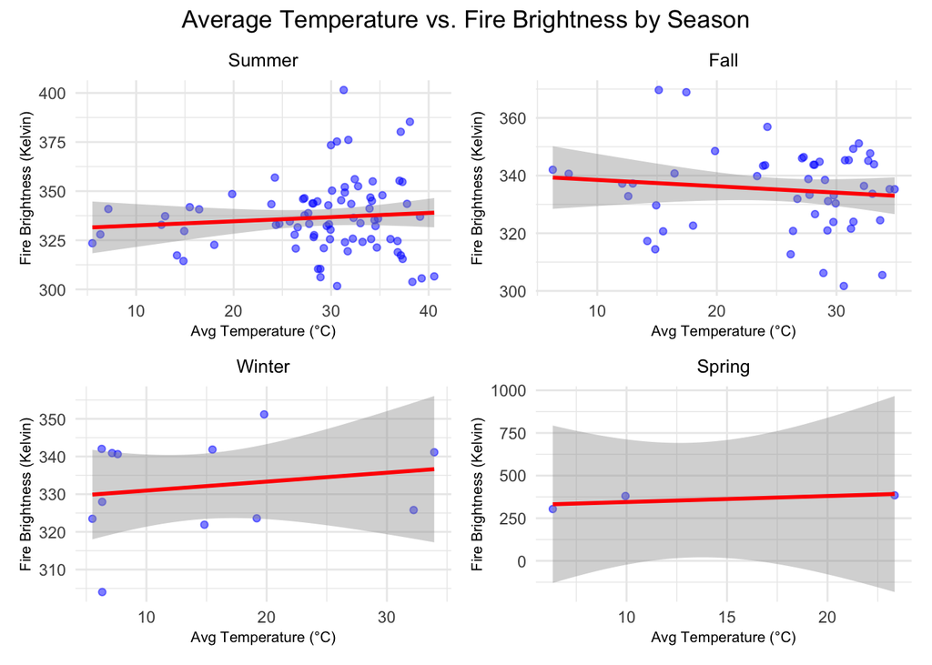

```r
# Need to recreate fire_data_brightness so that it includes avg_temp variable
fire_data_brightness <- fire_data %>%
  filter(!is.na(avg_brightness))

# organize data for each season
summer_fires_brightness <- fire_data_brightness %>%
  filter(Jun == 1 | Jul == 1 | Aug == 1)
fall_fires_brightness <- fire_data_brightness %>%
  filter(Sep == 1 | Oct == 1 | Nov == 1)
winter_fires_brightness <- fire_data_brightness %>%
  filter(Dec == 1 | Jan == 1 | Feb == 1)
spring_fires_brightness <- fire_data_brightness %>%
  filter(Mar == 1 | Apr == 1 | May == 1)


# Scatter plot for Summer Fires
plot_summer <- ggplot(summer_fires_brightness, aes(x = avg_temp, y = avg_brightness)) +
  geom_point(alpha = 0.5, color = "blue") +
  geom_smooth(method = "lm", color = "red") +
  labs(title = "Summer",
       x = "Avg Temperature (°C)", y = "Fire Brightness (Kelvin)") +
  theme_minimal()+
  theme(plot.title = element_text(size = 10),
  axis.title.x = element_text(size = 8),
  axis.title.y = element_text(size = 8) )

# Scatter plot for Fall Fires
plot_fall <- ggplot(fall_fires_brightness, aes(x = avg_temp, y = avg_brightness)) +
  geom_point(alpha = 0.5, color = "blue") +
  geom_smooth(method = "lm", color = "red") +
  labs(title = "Fall",
       x = "Avg Temperature (°C)", y = "Fire Brightness (Kelvin)") +
  theme_minimal()+
  theme(plot.title = element_text(size = 10),
  axis.title.x = element_text(size = 8),
  axis.title.y = element_text(size = 8) )

# Scatter plot for Winter Fires
plot_winter <- ggplot(winter_fires_brightness, aes(x = avg_temp, y = avg_brightness)) +
  geom_point(alpha = 0.5, color = "blue") +
  geom_smooth(method = "lm", color = "red") +
  labs(title = "Winter",
       x = "Avg Temperature (°C)", y = "Fire Brightness (Kelvin)") +
  theme_minimal()+
  theme(plot.title = element_text(size = 10),
  axis.title.x = element_text(size = 8),
  axis.title.y = element_text(size = 8) )

# Scatter plot for Spring Fires
plot_spring <- ggplot(spring_fires_brightness, aes(x = avg_temp, y = avg_brightness)) +
  geom_point(alpha = 0.5, color = "blue") +
  geom_smooth(method = "lm", color = "red") +
  labs(title = "Spring",
       x = "Avg Temperature (°C)", y = "Fire Brightness (Kelvin)") +
  theme_minimal()+
  theme(plot.title = element_text(size = 10),
  axis.title.x = element_text(size = 8),
  axis.title.y = element_text(size = 8) )

# Load patchwork library
library(patchwork)

# Combine all the plots in one row using patchwork with spacing adjustments
(plot_summer + plot_fall + plot_winter + plot_spring) +
  plot_layout(ncol = 2) +
  plot_layout(nrow = 2) +
  plot_annotation(title = "Average Temperature vs. Fire Brightness by Season") &
  theme(plot.title = element_text(hjust = 0.5))
```

Here we see there be a very slight positive correlation between temperature and fire brightness in the summer; however, in the fall we see a slight negative correlation. There is very little data for winter and spring and therefore no trends are evident. From this we can conclude that temperature does not appear to play a large role on fire brightness in our data set; however, it should be noted that a main limitation in this analysis is that only 110 variables had data on brightness, as we had to merge this data from a different fire data set (see Appendix). Perhaps if more fires had brightness data, trends would be present in the data.

## 4.5 Conclusion

From this analysis, it does not appear that higher temperatures lead to more intense fires. However, it is important to emphasize this may be due to limitations in the data. As previously discussed, the temperature data is not ideal for analyzing temperatures shocks. This data only reflects the 15th of each month and looking at daily max temperatures and highlighting extreme temperature shocks from the average would perhaps have different results.

- Fire Size and Temperature: A negative trend was initially observed across all seasons, where fire size seemed to decrease as temperatures rise. However, this relationship was likely influenced by extreme outliers. After removing outliers and focusing on fires exceeding 1,000 acres (to exclude small wildfires), we noticed a positive trend in fire size during the winter, but slight negative trends in the summer and fall. Further research may be able to better validate these trends.
- Fire Duration and Temperature: For the summer and fall seasons, as temperatures increase, fire duration tends to decrease. However, in winter, there was a positive trend, and spring shows no clear relationship between temperature and fire duration. When we analyzed only fires lasting less than 50 days, no relationship was identified in any season.
- Fire Brightness and Temperature: A very slight positive correlation was observed between temperature and fire brightness during the summer, while the fall showed a slight negative correlation. There was insufficient data in the winter and spring to discern any significant trends.

Overall, the relationship between temperature and wildfires shows seasonal variation, but we cannot establish a clear pattern between temperature and wildfire intensity. We will now explore another aspect of weather that may influence wildfire intensity.

# 5 Impact of Drought on Fire Behavior

Water availability and drought conditions are part of the main determinants of wildfire behavior, influencing both the likelihood of ignition and fire spread intensity. In this section, we assess the impact of drought on wildfires using the Standardized Precipitation-Evapotranspiration Index (SPEI). This index measures drought severity by accounting for both precipitation and temperature-driven evapotranspiration.

By incorporating this index into our analysis, we examine how different levels of drought conditions influenced key wildfire characteristics, including fire duration, fire intensity (brightness), and total acreage burned. Understanding this relationship is essential for assessing the role of water scarcity in wildfire events.

## 5.1 Data Preparation

We load and process wildfire data for California in 2020, selecting the variables of interest for our analysis. For further analyzing the impact of drought conditions accross seasons, we extract the seasons, and retrieve California’s boundary for spatial analysis.

```r
# Select relevant columns
fire_data<- fire_data %>%
  dplyr::select(geom, avg_brightness, ALARM_DATE, duration, GIS_ACRES)

# Convert date and extract year/month/season
fire_data <- fire_data %>%
  mutate(
    acq_date = as.Date(ALARM_DATE),
    year = year(ALARM_DATE),
    month = month(ALARM_DATE),
    season = case_when(
      month %in% c(12, 1, 2) ~ "Winter",
      month %in% c(3, 4, 5) ~ "Spring",
      month %in% c(6, 7, 8) ~ "Summer",
      month %in% c(9, 10, 11) ~ "Fall"
    )
  )
```

### 5.1.1 Load and process SPEI Index data

We load the SPEI Index data, extract time values, and assign each observation to a season and year. Next, we aggregate the 2020 SPEI values by season, crop the data to California’s boundary, and convert it into a dataframe. Finally, we rename the columns and compute the annual average SPEI for 2020 to prepare the data for analysis.

```r
# Load NetCDF file
nc_file <- "/Users/gretchenmoulton/Documents/GeoSpatial/share_2/spei01.nc"
spei_data <- rast(nc_file)

# Extract time values
time_values <- time(spei_data)
years <- year(time_values)
months <- month(time_values)

# Define seasons: Winter, Spring, Summer, Fall
season_index <- ifelse(months %in% c(12, 1, 2), "Winter",
                       ifelse(months %in% c(3, 4, 5), "Spring",
                              ifelse(months %in% c(6, 7, 8), "Summer", "Fall")))

# Combine season and year to avoid mixing different years
season_year_index <- paste(years, season_index, sep = "_")

# Aggregate SPEI by season using mean
spei_seasonal_2020 <- tapp(spei_data, index = season_year_index, fun = mean, na.rm = TRUE)

# Crop to California boundary
spei_california <- mask(crop(spei_seasonal_2020, vect(california_boundary)), vect(california_boundary))

# Convert raster to dataframe
df_spei <- as.data.frame(spei_california, xy = TRUE)

# Select relevant columns (x, y, and all X2020_* columns)
df_spei_selected <- df_spei %>%
  dplyr::select(x, y, starts_with("X2020_"))

# Rename columns using dplyr
df_spei <- df_spei_selected %>%
  rename(
    SPEI_2020_Winter = X2020_Winter,
    SPEI_2020_Spring = X2020_Spring,
    SPEI_2020_Summer = X2020_Summer,
    SPEI_2020_Fall = X2020_Fall
  )

df_spei$SPEI_2020 <- rowMeans(df_spei[, c("SPEI_2020_Winter", "SPEI_2020_Spring", "SPEI_2020_Summer", "SPEI_2020_Fall")], na.rm = TRUE)
```

We create a bounding box to define the plotting area and generate an inverted polygon to mask out regions outside California, ensuring that SPEI index pixels are only displayed within the California’s boundaries. In addition, we then convert the SPEI data into a spatial object, clip it to California’s boundary, and transform it into a dataframe for visualization.

```r
# Create a bounding box for the plot (covering the whole area)
plot_bbox <- st_bbox(c(xmin = -125, xmax = -114, ymin = 32, ymax = 42), crs = st_crs(4326))
plot_polygon <- st_as_sfc(plot_bbox)

# Create the inverted polygon (area outside California)
inverted_california <- st_difference(plot_polygon, st_union(california_boundary))
inverted_california <- st_make_valid(inverted_california)

# Prepare SPEI data
if (!exists("df_spei") || is.null(df_spei)) {
  stop("df_spei is not loaded. Please load your SPEI data.")
}
if (!all(c("x", "y", "SPEI_2020") %in% colnames(df_spei))) {
  stop("df_spei must contain columns 'x', 'y', and 'SPEI_2020'.")
}

# Convert SPEI data to sf object
spei_sf <- st_as_sf(df_spei, coords = c("x", "y"), crs = 4326)

# Clip SPEI data to **California only**
spei_sf_clipped <- st_intersection(spei_sf, california_boundary)

# Convert back to a dataframe for ggplot
df_spei_clipped_final <- data.frame(
  x = st_coordinates(spei_sf_clipped)[, 1],
  y = st_coordinates(spei_sf_clipped)[, 2],
  SPEI_2020 = spei_sf_clipped$SPEI_2020
)
```

## 5.2 Distribution of Wildfires Across Seasons

We create a bar plot to visualize the distribution of wildfire frequency and total acreage burned across seasons, allowing us to analyze seasonal variations in fire activity.

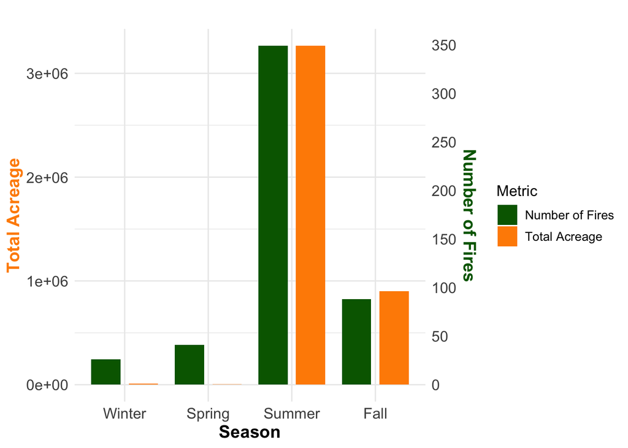

```r
# Create Bar Plot for Seasonal Fire Count and Acreage
fire_seasonal <- fire_2020 %>%
  group_by(season) %>%
  summarise(fire_count = n(),
            total_acreage = sum(GIS_ACRES, na.rm = TRUE))

# Define a scale factor to align fire count on a secondary y-axis
scale_factor <- max(fire_seasonal$total_acreage, na.rm = TRUE) / max(fire_seasonal$fire_count, na.rm = TRUE)

# Convert data to long format for proper bar grouping
fire_seasonal_long <- fire_seasonal %>%
  mutate(fire_count_scaled = fire_count * scale_factor) %>%
  pivot_longer(cols = c(total_acreage, fire_count_scaled),
               names_to = "Metric",
               values_to = "Value") %>%
  mutate(Metric = recode(Metric,
                         "total_acreage" = "Total Acreage",
                         "fire_count_scaled" = "Number of Fires"),
         season = factor(season, levels = c("Winter", "Spring", "Summer", "Fall")))  # Sort seasons

# Create the dual-axis bar plot with separated bars
ggplot(fire_seasonal_long, aes(x = season, y = Value, fill = Metric)) +
  geom_bar(stat = "identity", position = position_dodge(width = 0.9), width = 0.7) +

  # Define the primary y-axis for Total Acreage and secondary y-axis for Number of Fires
  scale_y_continuous(name = "Total Acreage",
                     sec.axis = sec_axis(~ . / scale_factor, name = "Number of Fires", breaks = seq(0, 350, 50))) +

  # Customize Colors
  scale_fill_manual(values = c("Total Acreage" = "darkorange", "Number of Fires" = "darkgreen")) +

  theme_minimal() +
  labs(title = "",
       x = "Season", fill = "Metric") +
  theme(axis.text = element_text(size = 12),
        axis.title.y.left = element_text(size = 14, face = "bold", color = "darkorange"),
        axis.title.y.right = element_text(size = 14, face = "bold", color = "darkgreen"),
        axis.title.x = element_text(size = 14, face = "bold"),
        legend.title = element_text(size = 12),
        legend.text = element_text(size = 10))
```

## 5.3 Drought Analysis

We create maps to analyze how wildfire duration, brightness (intensity), and acreage burned vary across California in relation to drought conditions to assess whether fires in drier regions tend to burn longer, more intensely, and over larger areas. The SPEI Index serves as the background layer, highlighting variations in water availability, while wildfire are mapped using distinct color gradients. The more negative the Index, the drier than normal conditions. This visualization helps spot patterns in wildfire behavior and gives insight into how drought influences fire spread and intensity.

### 5.3.1 Duration

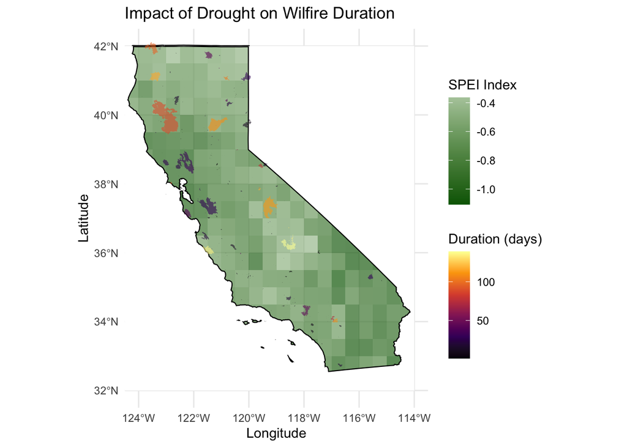

```r
# Plot duration
ggplot() +
  # SPEI Index
  geom_tile(data = df_spei, aes(x = x, y = y, fill = SPEI_2020), alpha = 0.7, color = NA) +
  scale_fill_gradient2(low = "darkgreen", mid = "white", high = "blue", midpoint = 0, name = "SPEI Index") +

  # Overlay New Fill Scale
  ggnewscale::new_scale_fill() +

  # California Boundary Outline
  geom_sf(data = california_boundary, fill = NA, color = "black", linewidth = 0.8) +

  # Inverted Mask
  geom_sf(data = inverted_california, fill = "white", color = NA, alpha = 1) +

  geom_sf(data = fire_2020 %>% filter(season %in% c("Summer", "Fall")),
          aes(fill = duration), alpha = 0.6, color = NA) +
  scale_fill_viridis_c(option = "inferno", name = "Duration (days)") +

  # Labels and Theme
  theme_minimal() +
  theme(
    panel.background = element_rect(fill = "white", color = NA),
    plot.background = element_rect(fill = "white", color = NA)
  ) +
  labs(x = "Longitude", y = "Latitude",
       title = "Impact of Drought on Wilfire Duration") +
  coord_sf(xlim = c(-124, -114), ylim = c(32, 42))  # Adjust plot limits
```

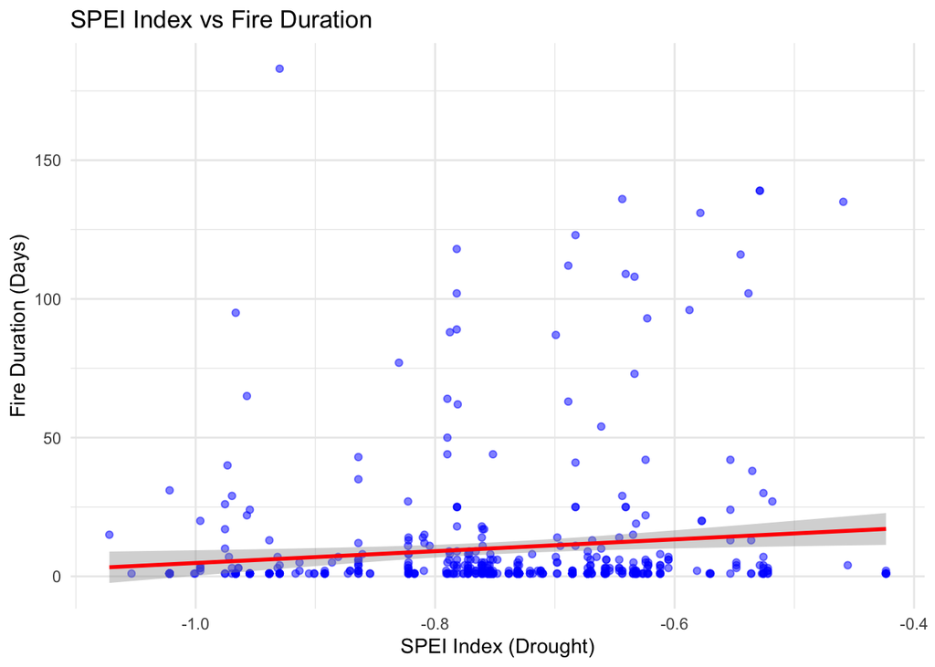

```r
# Convert df_spei to sf points
spei_points <- st_as_sf(df_spei, coords = c("x", "y"), crs = 4326)

# Spatial join
fire_2020_centroids <- st_centroid(fire_2020)

# Join fires to SPEI cells
fire_with_spei <- st_join(fire_2020_centroids, spei_points, join = st_nearest_feature)

# Plot
ggplot(data = fire_with_spei, aes(x = SPEI_2020, y = duration)) +
  geom_point(alpha = 0.5, color = "blue") +
  geom_smooth(method = "lm", color = "red") +
  labs(title = "SPEI Index vs Fire Duration",
       x = "SPEI Index (Drought)",
       y = "Fire Duration (Days)") +
  theme_minimal()
```

The scatterplot reveals that longer-duration fires tend to occur under wetter conditions (higher SPEI values), contrary to the expectation that severe drought drives longer fires. This may be because wetter periods promote vegetation growth, increasing fuel availability. When these areas eventually ignite, the abundance of fuel can sustain fires for longer durations, suggesting that fuel accumulation, rather than drought severity alone, plays a key role in fire persistence.

### 5.3.2 Burned Acreage

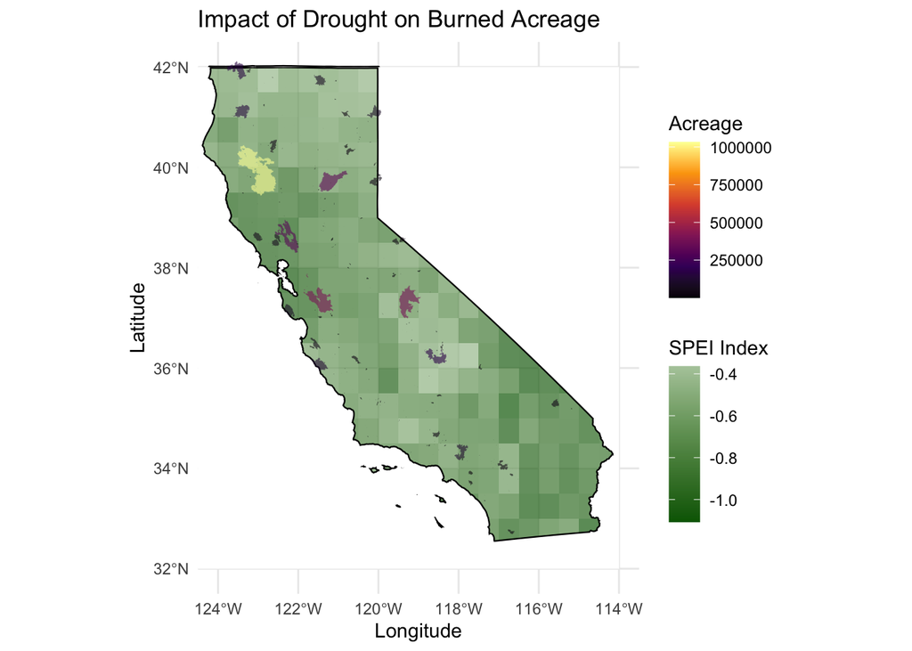

```r
# Plot acreage
ggplot() +
  # SPEI Index
  geom_tile(data = df_spei, aes(x = x, y = y, fill = SPEI_2020), alpha = 0.7, color = NA) +
  scale_fill_gradient2(low = "darkgreen", mid = "white", high = "blue", midpoint = 0, name = "SPEI Index") +

  # Overlay New Fill Scale
  ggnewscale::new_scale_fill() +

  # California Boundary Outline
  geom_sf(data = california_boundary, fill = NA, color = "black", linewidth = 0.8) +

  # Inverted Mask
  geom_sf(data = inverted_california, fill = "white", color = NA, alpha = 1) +

  geom_sf(data = fire_2020 %>% filter(season %in% c("Summer", "Fall")),
          aes(fill = GIS_ACRES), alpha = 0.6, color = NA) +
  scale_fill_viridis_c(option = "inferno", name = "Acreage") +

  # Labels and Theme
  theme_minimal() +
  theme(
    panel.background = element_rect(fill = "white", color = NA),
    plot.background = element_rect(fill = "white", color = NA)
  ) +
  labs(x = "Longitude", y = "Latitude",
       title = "Impact of Drought on Burned Acreage") +
  coord_sf(xlim = c(-124, -114), ylim = c(32, 42))  # Adjust plot limits
```

[figure not shown]

```r
# Filter out extreme outliers
fire_filtered <- fire_with_spei %>%
  filter(GIS_ACRES < 200000)

# Plot
ggplot(data = fire_filtered, aes(x = SPEI_2020, y = GIS_ACRES)) +
  geom_point(alpha = 0.5, color = "blue") +
  geom_smooth(method = "lm", color = "red") +
  labs(title = "SPEI Index vs Fire Duration",
       x = "SPEI Index (Drought)",
       y = "Burned Acreage") +
  theme_minimal()
```

### 5.3.3 Brightness

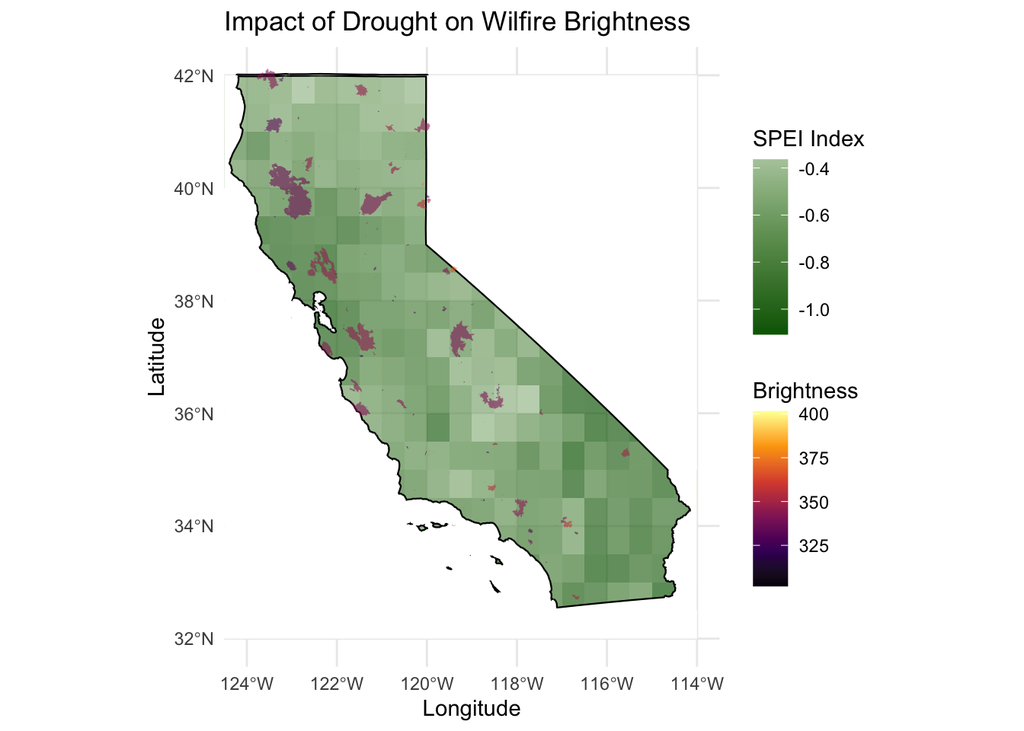

```r
# Plot brightness
ggplot() +
  # SPEI Index
  geom_tile(data = df_spei, aes(x = x, y = y, fill = SPEI_2020), alpha = 0.7, color = NA) +
  scale_fill_gradient2(low = "darkgreen", mid = "white", high = "blue", midpoint = 0, name = "SPEI Index") +

  # Overlay New Fill Scale
  ggnewscale::new_scale_fill() +

  # California Boundary Outline
  geom_sf(data = california_boundary, fill = NA, color = "black", linewidth = 0.8) +

  # Inverted Mask
  geom_sf(data = inverted_california, fill = "white", color = NA, alpha = 1) +

  geom_sf(data = fire_2020 %>% filter(season %in% c("Summer", "Fall")),
          aes(fill = avg_brightness), alpha = 0.6, color = NA) +
  scale_fill_viridis_c(option = "inferno", name = "Brightness") +

  # Labels and Theme
  theme_minimal() +
  theme(
    panel.background = element_rect(fill = "white", color = NA),
    plot.background = element_rect(fill = "white", color = NA)
  ) +
  labs(x = "Longitude", y = "Latitude",
       title = "Impact of Drought on Wilfire Brightness") +
  coord_sf(xlim = c(-124, -114), ylim = c(32, 42))  # Adjust plot limits
```

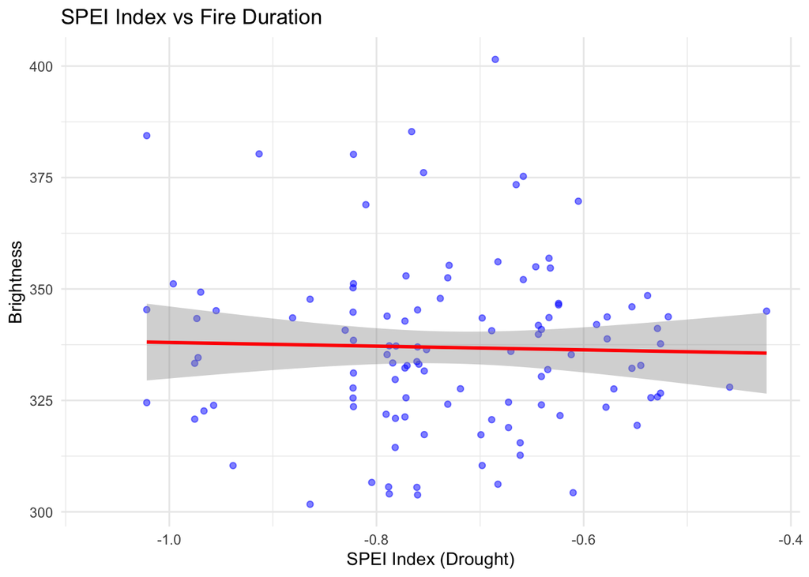

```r
# Plot
ggplot(data = fire_with_spei, aes(x = SPEI_2020, y = avg_brightness)) +
  geom_point(alpha = 0.5, color = "blue") +
  geom_smooth(method = "lm", color = "red") +
  labs(title = "SPEI Index vs Fire Duration",
       x = "SPEI Index (Drought)",
       y = "Brightness") +
  theme_minimal()
```

The graph shows that wildfire brightness (intensity) is relatively consistent across different drought conditions and fire sizes, suggesting that brightness is more influenced by fuel type and combustion dynamics rather than total acreage burned. Even small fires can burn at high intensity if the fuel is dry and dense, while larger fires may not always exhibit the highest brightness. Factors like wind, oxygen supply, and vegetation type likely play a bigger role in determining fire intensity than drought severity alone. The scatterplot supports this, showing little to no correlation between SPEI and brightness. This suggests that fire intensity is likely driven by other factors rather than the level of drought stress.

## 5.4 Conclusion

In summary, while drought conditions (low SPEI values) are generally more severe in southern California, northern California also experiences localized drought pockets. However, larger and longer-lasting wildfires are more common in the north, suggesting that drought alone does not fully explain fire behavior. The weak relationship between drought severity and fire duration, burned acreage, or brightness indicates that factors like fuel accumulation, vegetation density, and local terrain may play a more significant role. In fact, wetter or moderately dry conditions may promote vegetation growth, increasing fuel loads and contributing to larger fires. Meanwhile, fire brightness appears relatively stable across drought levels, reinforcing that combustion dynamics and fuel characteristics, rather than drought severity, primarily shape fire intensity.

# 6 Impact of Slope on Wildfire Behavior

In this section we are going to concentrate on the relation of wildfires and the slope of the land. Our first intuition is that fires that occure on a highly sloped area, spreads faster and is harder to kill since getting all the machinery there is more complicated than killing fires on flatter land. Thinking further we also notice that generally flat areas are more prone to become populated land where building villages in sloped areas is harder. Therefore sloped areas are more likely to have coverage that is burnable whereas flat areas that are used for housing, manufacturing, etc. are more likely concrete area which is not going to burn as easily.

## 6.1 Elevation of California

As a first step we need to actually get data on the topic of Elevation. The data we use is provided by “AWS” - Amazon Web Services and can be accessed through the package “elevatr”. To download California-specific data we create a coordinate-rectangle which covers an area of the world surface that contains California and download data restricted to this created rectangle. The resolution of the downloaded data can be chosen in the “z” parameter where 8 stands for resolution 250m per pixel; 9 stands for 90m pp and 10 stands 30m pp. We decided to load our data with a resolution-parameter of 10 so 30m pp as we want our data as detailed as possible and considering we are talking about slope which is measured in degrees (0° - 90°) we think a difference of 60m pp is a drastic difference and the loading time of the data does not increase insanely much by setting the resolution that high therefore we think it is worth the trade-off. Anyways loading the data takes some time, and we don’t want to wait each time we run the code, we store this raster-object so we can access it faster. As we downloaded just a rectangle of data that covers the area of California but what we are interested in is the shape of the actual state, we also crop this down so it matches the state boundaries.

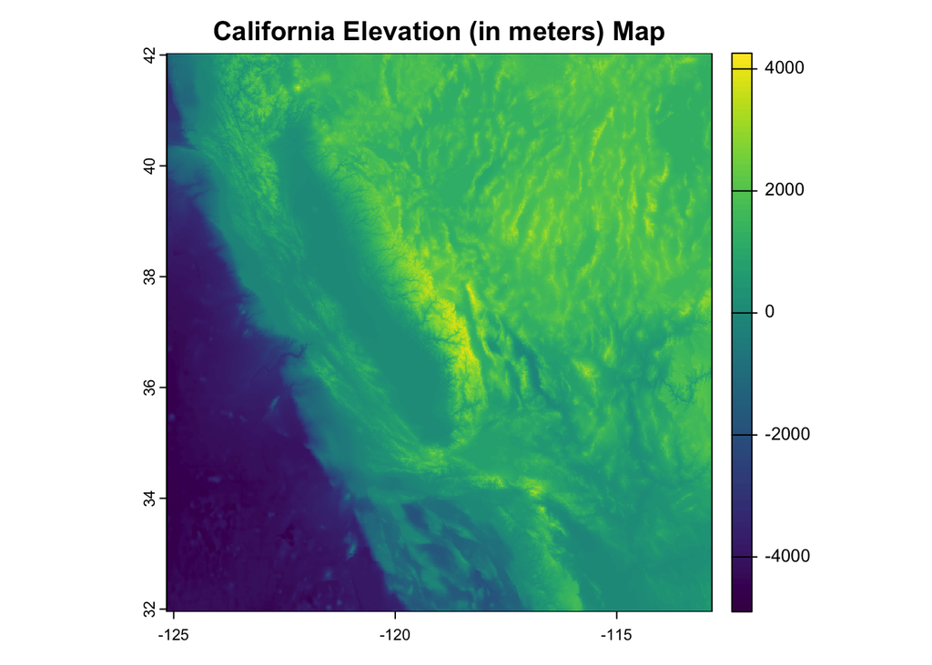

```r
#Load data about the elevation of California.
#Got that from a package but then saved it and now only read because the downloading takes some time
# Define bounding box for California (xmin, ymin, xmax, ymax)
cali_bbox <- st_as_sf(data.frame(
  x = c(-125, -113),
  y = c(32, 42)
), coords = c("x", "y"), crs = 4326)  # Define as spatial object

# Download elevation data (z = 8 for resolution ca 250m per pixel; 9 : 90m pp; 10: 30m pp)
 elevation_cali <- get_elev_raster(cali_bbox, z = 10, src = "aws")

# saveRDS(elevation_cali_raster, "/Users/danielaguggenberger/Documents/Dokumente - MacBook Air von Daniela/BSE/GeoSpatial/project/data/elevation_cali_10.rds")

 #elevation_cali <- readRDS("/Users/danielaguggenberger/Documents/Dokumente - MacBook Air von Daniela/BSE/GeoSpatial/project/data/elevation_cali_10.rds")

# Convert to SpatRaster format
elevation_cali_raster <- rast(elevation_cali)

#see what we have so far
plot(elevation_cali_raster, main = "California Elevation (in meters) Map")
```

```r
#crop this so we only have the part actually inside of california left
#the regular data downloaded is a whole square.
cali_elevation_raster_cropped <- crop(elevation_cali_raster, california_boundary_sf)
```

```
## |---------|---------|---------|---------|=========================================
```

```r
masked_raster <- mask(cali_elevation_raster_cropped, california_boundary)
```

```
## |---------|---------|---------|---------|=========================================                                          |---------|---------|---------|---------|=========================================
```

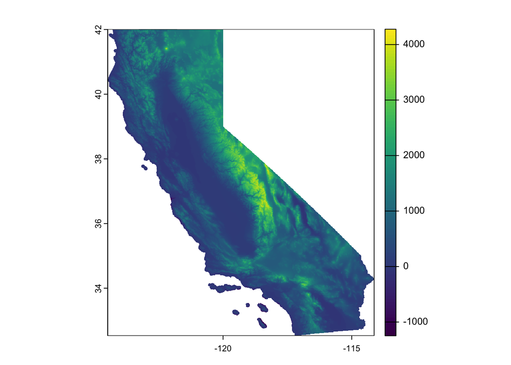

```r
# Plot the final result
plot(masked_raster)
```

The above seen map indicated the elevation of the land measured in meters where lighter and more green/yellow areas are higher while darker and blue areas indicate lower areas of land. Since we don’t want to analyse the relationship about fires and elevation of land but rather with slope of land, we have to compute such a parameter at each point of the land. We do that by manipulating our elevation data. Once we created a map indicating the slope at each point of land we now assign every FIRE its own slope parameter. Since fires cover more than only a point on the map, we assign each fire the average slope of the land it covers.

```r
# Compute slope from elevation raster
slope_raster <- terrain(elevation_cali_raster, v = "slope", unit = "degrees")
```

```
## |---------|---------|---------|---------|=========================================
```

```r
# Extract slope values at fire locations
fire_slope <- extract(slope_raster, fire_data)

#this now has 1130869 rows; because each fire is a polygon covering an area --> not necessarily a constant slope but multiple
#compute the average of each polygon so that matches the 505 rows we have in the fire_data --> 505 fires

#Aggregate slope values
fire_slope <- fire_slope %>%
  group_by(ID) %>%
  summarize(slope = mean(slope, na.rm = TRUE))

# Add slope values to fire_data and fire_data_simplified
fire_data_simplified$slope <- fire_slope$slope
fire_data$slope <- fire_slope$slope
```

## 6.2 Slope of the Land

Now as we have the data we need in the correct formats, we check if there is a visual relation as we would expect it on the slope of land and the occurrence of wildfires!

```r
#see if there is a relationship between the slope and the occurrence of a fire

#_____first show on map
# Ensure both spatial objects are in the same projection (WGS84 - EPSG:4326)
california_boundary_sf <- st_as_sf(california_boundary)
california_boundary_sf <- st_transform(california_boundary_sf, crs = st_crs(slope_raster))  # Transform the California map to match the raster CRS

# Crop the slope raster to the extent of California
slope_cali <- crop(slope_raster, extent(california_boundary_sf))
```

```
## |---------|---------|---------|---------|=========================================
```

```r
slope_cali_masked <- mask(slope_cali, california_boundary_sf)
```

```
## |---------|---------|---------|---------|=========================================                                          |---------|---------|---------|---------|=========================================
```

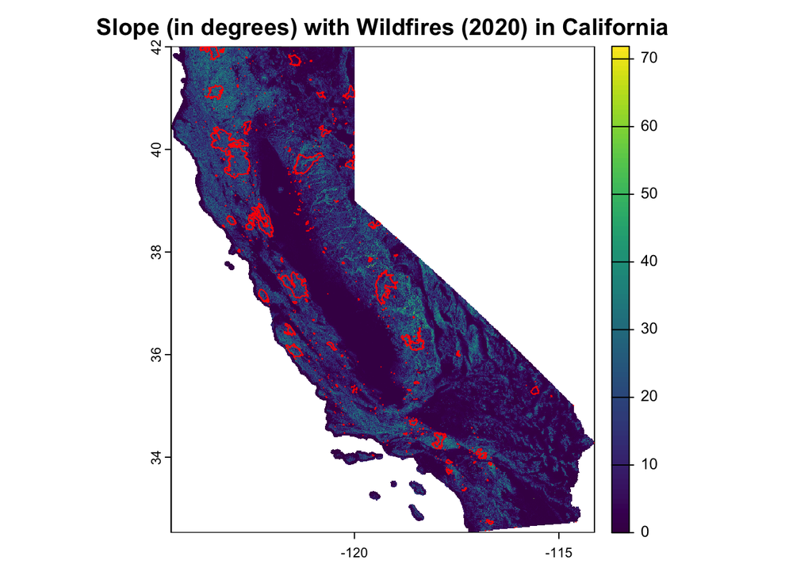

```r
fire_data_simplified_cali <- st_intersection(fire_data_simplified, california_boundary_sf)

# Plot the slope map with wildfires within California
plot(slope_cali_masked, main = "Slope (in degrees) with Wildfires (2020) in California")
plot(st_geometry(fire_data_simplified_cali), add = TRUE, col = NA, border = "red", pch = 16, cex = 0.5)
```

```r
#no fires on the big batch in the middle with very low slope
```

The visual inspection indicates what we were expecting. We see more fires in brighter areas on the map indicating higher slopes. The big dark batch in the middle only has some small fires while way more and way bigger fires occur on the mountainous area around it.

Let us now look into that topic further. We also want to look at some numbers, therefore we compare the average slope of places that have a fire occurred on them in 2020 with the average slope of areas without any fires that year. When talking about unaffected areas we have to limit analysis to a random sample of places without a fire. When taking every point that has no fire in 2020 into account, this gives us an object with the size of 2,6GB which is not feasible for this purpose.

```r
# Ensure fire data is in the same CRS as the slope raster
fire_data <- st_transform(fire_data, crs(slope_raster))

# Rasterize the fire data to match the slope raster resolution
fire_raster <- rasterize(fire_data, slope_raster, field = 1, background = 0)
```

```
## |---------|---------|---------|---------|=========================================
```

```r
# Extract slope values for burned areas
burned_slope_values <- values(slope_raster)[values(fire_raster) == 1]

# Extract slope values for unburned areas
unburned_slope_values <- values(slope_raster)[values(fire_raster) == 0]
# Randomly sample a fraction of the unburned slope values
set.seed(123)  # For reproducibility
sample_fraction <- 0.01  # Adjust this fraction as needed
sampled_unburned_slope_values <- sample(unburned_slope_values, size = length(unburned_slope_values) * sample_fraction)


t.test(burned_slope_values, unburned_slope_values)
```

```
##
##  Welch Two Sample t-test
##
## data:  burned_slope_values and unburned_slope_values
## t = 2546.9, df = 4657783, p-value < 2.2e-16
## alternative hypothesis: true difference in means is not equal to 0
## 95 percent confidence interval:
##  10.37658 10.39257
## sample estimates:
## mean of x mean of y
## 16.409146  6.024573
```

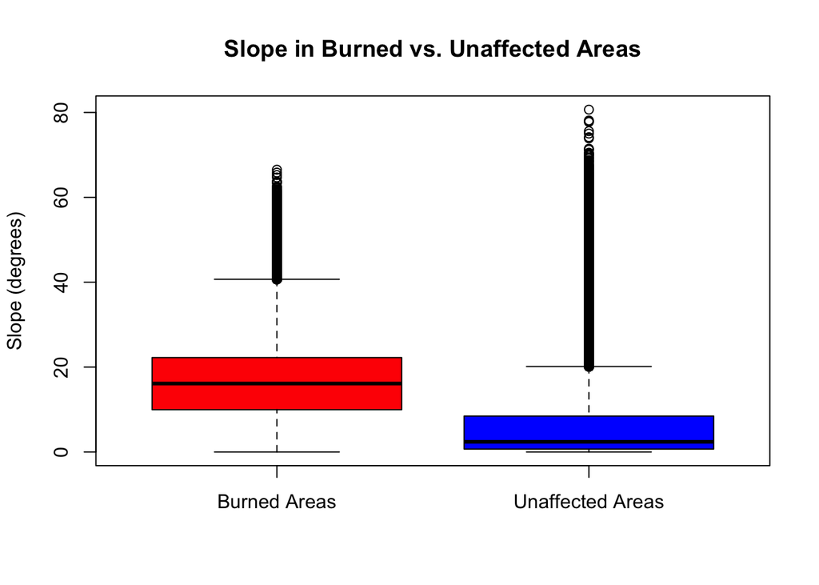

```r
boxplot(burned_slope_values, sampled_unburned_slope_values,
        names = c("Burned Areas", "Unaffected Areas"),
        main = "Slope in Burned vs. Unaffected Areas",
        ylab = "Slope (degrees)", col = c("red", "blue"))
```

After the visual inspection we also compute a statistical t-test analyzing our question of interest: Does the slope of places where fires happen differ significantly from the slope of areas where no fires appear?

We create a Welch Two Sample t-test to compare the mean slope of burned areas and unaffected areas. As seen above we receive a test-value of 2546.9 already indicating a strong difference between the two groups. To check if the difference is statistically significant we observe a p-value < 2.2e-16 which is clearly under the 0,05 benchmark indicating a highly significant result of our test.

## 6.3 Slope and Fire Duration

Now we know that fires occur more in places with higher slope, we also want to know of there is a relationship between the slope and the duration of fires.

Now see the magnitude of the relationship between slope and fires.

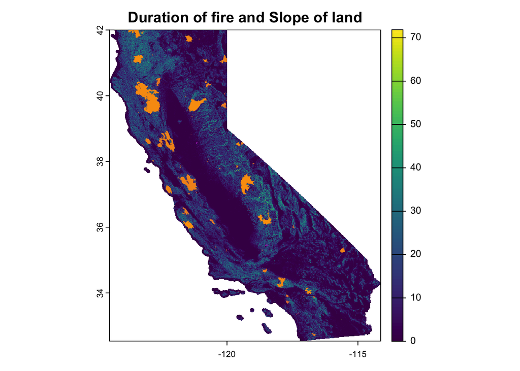

```r
# Create a custom color palette
custom_palette <- colorRampPalette(c("purple", "orange"))
# Map duration to custom colors
duration_colors <- custom_palette(length(fire_data_simplified_cali$duration))[rank(fire_data_simplified_cali$duration)]
# Plot the slope map
plot(slope_cali_masked, main = "Duration of fire and Slope of land")

# Overlay fire data, filled with custom colors based on duration (no border)
plot(st_geometry(fire_data_simplified_cali), add = TRUE,
     col = duration_colors,
     border = NA,
     pch = 16, cex = 0.5)
```

The visual inspection does not get us far here. We don’t see much difference in the color of the fires indicating its duration. Therefore we again look at some numbers.

```r
# Correlation between slope and fire duration
correlation <- cor(fire_data$slope, fire_data$duration, use = "complete.obs")
print(paste("Correlation between slope and fire duration:", correlation))       #Corr=0.274
```

```
## [1] "Correlation between slope and fire duration: 0.274499456354225"
```

```r
# Linear regression: Fire duration ~ Slope
model <- lm(fire_data$duration ~ slope, data = fire_data)
summary(model)
```

```
##
## Call:
## lm(formula = fire_data$duration ~ slope, data = fire_data)
##
## Residuals:
##     Min      1Q  Median      3Q     Max
## -25.782 -10.142  -4.178  -0.653 162.994
##
## Coefficients:
##             Estimate Std. Error t value Pr(>|t|)
## (Intercept)   1.0260     1.7821   0.576    0.565
## slope         0.8989     0.1420   6.332 5.46e-10 ***
## ---
## Signif. codes:  0 '***' 0.001 '**' 0.01 '*' 0.05 '.' 0.1 ' ' 1
##
## Residual standard error: 23.57 on 492 degrees of freedom
##   (11 observations deleted due to missingness)
## Multiple R-squared:  0.07535,    Adjusted R-squared:  0.07347
## F-statistic: 40.09 on 1 and 492 DF,  p-value: 5.463e-10
```

We observe a correlation of 0.274 between the slope and the duration of fires. A very easy linear regression of the effect of the slope on the duration without any controls, gives us the statistics shown above. Namely a highly significant result indicating a increase of 0.89 days of duration associated with a 1 degree increase of slope. This result might seem a bit drastic at first sight but when we think about how slope is measured and how small the differences in most of the places are, we can understand that result better.

## 6.4 Slope and fire Size

Related to the last part where we saw a relationship between the slope and the occurrence of a fire and the relation of the slope and the duration of a fire, we now want to see if there also is a relationship between the slope and the size of the fire. We expect to see a relationship there due to the increase of duration at areas with higher slope and due the reasoning we gave in the beginning stating that it is harder to kill fires on more sloped areas than on flat land which can lead to giving the fire more time to spread.

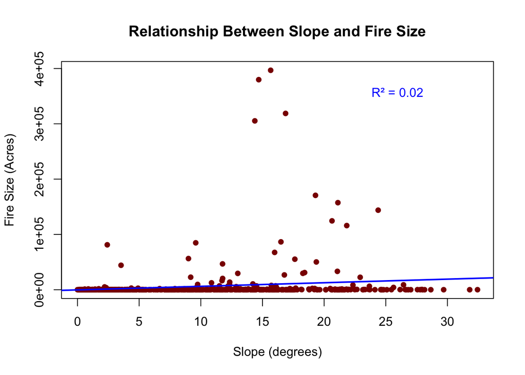

```r
# Remove the outlier (fire size > 8e+05 acres)
fire_data <- fire_data[fire_data$GIS_ACRES <= 8e+05, ]

# Scatter plot of slope vs. fire size
plot(fire_data$slope, fire_data$GIS_ACRES,
     xlab = "Slope (degrees)",
     ylab = "Fire Size (Acres)",
     main = "Relationship Between Slope and Fire Size",
     pch = 16, col = "darkred")


# Fit a linear model
lm_model <- lm(GIS_ACRES ~ slope, data = fire_data)

# Add the trendline to the plot
abline(lm_model, col = "blue", lwd = 2)

# Add the R-squared value to the plot
r_squared <- summary(lm_model)$r.squared
text(x = max(fire_data$slope) * 0.8, y = max(fire_data$GIS_ACRES) * 0.9,
     labels = paste("R² =", round(r_squared, 2)), col = "blue")
```

```r
# Correlation between slope and fire size
correlation <- cor(fire_data$slope, fire_data$GIS_ACRES, use = "complete.obs")
print(paste("Correlation between slope and fire size:", correlation))       #Corr: 0.13
```

```
## [1] "Correlation between slope and fire size: 0.138441416831486"
```

As we can see there might be a slight connection between bigger fires and greater slopes, but there is no clear trend or pattern we can observe.

## 6.5 Conclusion

Summing up, looking at the effect the slope of the land has on the data we see some impressive results which mostly align with our intuition we had in the beginning. We see a statistically significant difference in the slope of areas that where burned in 2020 and areas that did not happen to be the place of a fire in said year. We observe a clear pattern there. Similar holds for the relationship between slope and fire duration. A increase in the slope by 1° is associated with a 0.89 day increase in the fire duration. For the relationship between slope and fire size we were not able to see a clear pattern.

# 7 Effects of Land Cover and Human Settlement Proximity on Wildfire Behavior

This part of analysis focuses on two critical determinants of wildfire impact:

1. the proximity of fires to populated areas.
2. the types of land cover affected by these fires. These factors are essential for understanding both the human impact and ecological significance of wildfire events.

Understanding the spatial relationship between wildfire perimeters and population centers is crucial for several reasons:

- Emergency Response Planning: By quantifying the distance between fires and communities, emergency management can better prioritize resources and evacuation efforts for the most at-risk populations.
- Public Health Implications: Even communities not directly threatened by flames can experience significant health impacts from smoke and air quality degradation, which are influenced by proximity to active fires.
- Urban-Wildland Interface: As California’s development continues to expand into previously wild areas, the interface between human settlements and fire-prone landscapes becomes increasingly important to map and understand.

Our analysis uses Geospatial techniques to measure distances between city centroids and fire perimeters, identifying communities within critical distance thresholds (particularly those within 50km of fire boundaries).

## 7.1 City Proximity Analysis

```r
# Read Fire Data (2020 only)
data <- st_read("/Users/gretchenmoulton/Documents/GeoSpatial/share_2/California_Fire_Perimeters_(all)/California_Fire_Perimeters_(all).shp")
data <- data %>% filter(YEAR_ == 2020)

# Read the “Places” shapefile
# Loading this to get info about cities
places <- st_read("/Users/gretchenmoulton/Documents/GeoSpatial/tl_2020_06_place/tl_2020_06_place.shp")
# Reproject all layers to EPSG:3310 at the start
data_3310 <- st_transform(data, 3310)
CA_3310 <- st_transform(california_boundary, 3310)
places_ca_centroids_3310 <- st_centroid(st_transform(places, 3310))

# Combine all fire polygons into one and compute centroid
fire_union_3310 <- st_union(data_3310)
fire_union_centroid_3310 <- st_centroid(fire_union_3310)
```

### 7.1.1 Distance from each city centroid to the fire boundary and union centroid

```r
# Distance from each city centroid to the fire boundary and union centroid
places_ca_centroids_3310$dist_to_fire_boundary <- st_distance(places_ca_centroids_3310, fire_union_3310)
places_ca_centroids_3310$dist_to_fire_union_centroid <- st_distance(places_ca_centroids_3310, fire_union_centroid_3310)

# Compute centroids of individual fires and their distances to cities
fire_centroids_3310 <- st_centroid(data_3310)
city_fire_matrix <- st_distance(places_ca_centroids_3310, fire_centroids_3310)

# Extract the nearest fire centroid distance per city
places_ca_centroids_3310$dist_to_nearest_fire_centroid <- rowMins(city_fire_matrix)
```

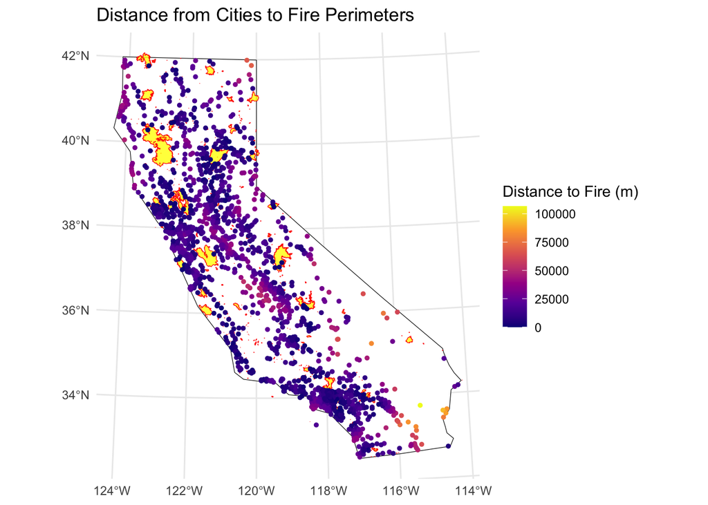

```r
ggplot() +
  # California boundary
  geom_sf(data = CA_3310, fill = "white", color = "black") +

  # Fire polygons
  geom_sf(data = data_3310, fill = "yellow", alpha = 0.8, color = "red") +

  # City centroids, colored by distance to boundary
  geom_sf(
    data = places_ca_centroids_3310,
    aes(color = as.numeric(dist_to_fire_boundary)),
    size = 1
  ) +

  scale_color_viridis_c(option = "plasma") +
  theme_minimal() +
  labs(
    color = "Distance to Fire (m)",
    title = "Distance from Cities to Fire Perimeters"
  )
```

This map illustrates the proximity of California cities to fire perimeters during the 2020 wildfire season. Each dot represents a population center, with colors indicating distance to the nearest fire - dark blue/purple dots show cities very close to fire boundaries (under 25,000 meters), while yellow dots represent locations around 100,000 meters from fires.

The visualization reveals that northern and central California experienced widespread fire proximity, with many communities in dangerously close range. The clustering of dark blue dots throughout the state highlights how the 2020 fire season created high-risk conditions for numerous populated areas, particularly **along the northern coast and central regions**. Some communities in the eastern inland areas appear to have maintained safer distances from fire perimeters.

### 7.1.2 Focusing on Close Proximity - 50 Kilometers

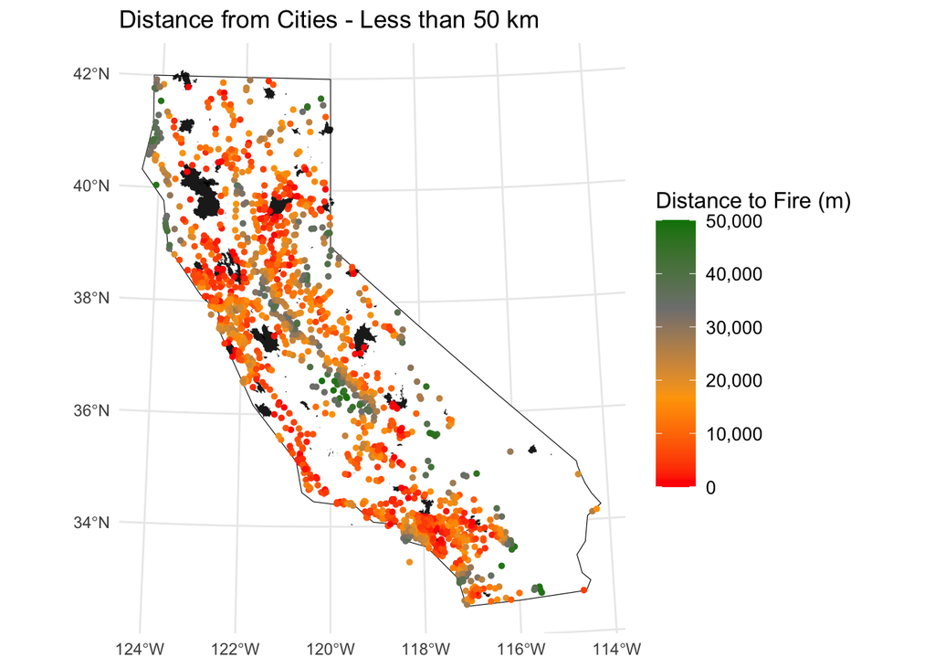

```r
#### Fire Proximity - Filter 50km

# 1. Convert distance units to numeric (removing "units" class):
places_ca_centroids_3310$dist_num <- as.numeric(places_ca_centroids_3310$dist_to_fire_boundary)

# 2. Filter for distances less than 50 km (50,000 meters):
cities_close <- places_ca_centroids_3310 %>%
  filter(dist_num <= 50000)

ggplot() +
  geom_sf(data = CA_3310, fill = "white", color = "black") +
  geom_sf(data = data_3310, fill = "black", alpha = 0.9, color = NA) +
  geom_sf(
    data = cities_close,
    aes(color = as.numeric(dist_to_fire_boundary)),
    size = 1
  ) +
  scale_color_gradientn(
  colors = c("#FF0000", "#FFA500", "#808080", "#008000"),
  limits = c(0, 50000),  # Explicitly set the range
  breaks = c(0, 10000, 20000, 30000, 40000, 50000),
  labels = c("0", "10,000", "20,000", "30,000", "40,000", "50,000")
  ) +
  guides(
    # Make the colorbar bigger/taller, with some padding
    color = guide_colorbar(
      barwidth = 1.5,    # width of the bar in "plot" units
      barheight = 10,    # height of the bar in "plot" units
      title.position = "top"  # puts the legend title on top
    )
  ) +
  theme_minimal() +
  theme(
    legend.title = element_text(size = 12),
    legend.text  = element_text(size = 10)
  ) +
  labs(
    color = "Distance to Fire (m)",
    title = "Distance from Cities - Less than 50 km"
  )
```

This map focuses specifically on California cities within 50 kilometers of fire perimeters. The color gradient ranges from bright red (0 km, directly at the fire boundary) through orange (around 10-20 km) to grayish-green (40-50 km). The 50 km threshold is particularly interesting because it represents a **critical emergency management boundary**. At this distance:

- Communities have minimal **evacuation time** if fire behavior changes rapidly
- **Air quality** impacts become significant for sensitive populations
- **Local resources and infrastructure** may be strained by nearby fire response
- It represents approximately a 30-45 minute drive time, a realistic evacuation zone

What’s striking in this visualization is how many populated areas fall within this high-risk zone. The map reveals dense clusters of red and orange dots (cities within 0-20 km of fires) throughout Central California coastal area such as San Francisco Bay Area and along the Gold Country, while the southern coastal regions also show significant vulnerability. By eliminating cities beyond the 50 km threshold, this map effectively highlights the **communities most directly threatened** by California’s devastating 2020 fire season, showing the widespread nature of immediate fire risk across the state.

### 7.1.3 Ranking of the cities at highest risk in 2020

Top 20 closest cities to fire boundaries

```r
# Ensure the distance column is numeric
places_ca_centroids_3310 <- places_ca_centroids_3310 %>%
  mutate(dist_num = as.numeric(dist_to_fire_boundary))

# Filter cities that are within 50 km (i.e., less than 50,000 m)
cities_50 <- places_ca_centroids_3310 %>%
  filter(dist_num < 50000) %>%   # 50 km threshold
  arrange(dist_num)               # Rank in ascending order (closest first)

# Extract a list with city names, distances, and coordinates
cities_list <- dplyr::select(st_drop_geometry(cities_50), Community = NAME, Distance = dist_num)

head(cities_list,20)
```

```
##           Community  Distance
## 1       Berry Creek   0.00000
## 2         Big Creek   0.00000
## 3        Bonny Doon   0.00000
## 4       Cedar Slope   0.00000
## 5         Deer Park   0.00000
## 6        Forbestown   0.00000
## 7        Happy Camp   0.00000
## 8          Loma Mar   0.00000
## 9  Moskowite Corner   0.00000
## 10              Ono   0.00000
## 11             Ruth   0.00000
## 12    Sequoia Crest   0.00000
## 13      Shaver Lake   0.00000
## 14  Williams Canyon   0.00000
## 15         Modjeska  29.49649
## 16    Boulder Creek  53.50720
## 17         Monrovia  57.69122
## 18        Pierpoint  58.12320
## 19        Brookdale  83.68816
## 20           Walker 104.80624
```

First 14 communities actually were at the epicenter of the wildfires;

### 7.1.4 Population-Weighted Risk Analysis for California Wildfires

Population-Weighted Risk Analysis for California Wildfires is essential because it provides a **more accurate representation of human impact than raw geographical proximity** alone. By accounting for both a community’s distance from fires and its population size, this approach highlights areas where large numbers of people are endangered, not just geographical points on a map.

```r
# This part extends our existing analysis to include population weighting

# Check if the places shapefile has population data
if("POP10" %in% colnames(places) || "POPULATION" %in% colnames(places)) {
  # If population field already exists, use it
  pop_field <- ifelse("POP10" %in% colnames(places), "POP10", "POPULATION")

  # Join population to your existing centroids dataframe
  places_ca_centroids_3310 <- places_ca_centroids_3310 %>%
    left_join(st_drop_geometry(places) %>%
              dplyr::select(GEOID, NAME, !!sym(pop_field)),
              by = c("GEOID"))

  # Rename the population field to be consistent
  places_ca_centroids_3310 <- places_ca_centroids_3310 %>%
    rename(Population = !!sym(pop_field))
} else {
  # If no population data is available, we need to get it from Census API
  # or another source. This example uses the tidycensus package.

  # Install if needed
  if(!require(tidycensus)) {
    install.packages("tidycensus")
    library(tidycensus)
  }


  # Get population data for places in California
  ca_places_pop <- get_decennial(
    geography = "place",
    variables = "P1_001N", # Total population
    state = "CA",
    year = 2020,
    geometry = FALSE
  )

  # Clean up the data
  ca_places_pop <- ca_places_pop %>%
    rename(Population = value) %>%
    dplyr::select(GEOID, NAME, Population)

  # Join to your centroids
  places_ca_centroids_3310 <- places_ca_centroids_3310 %>%
    left_join(ca_places_pop, by = c("GEOID"))
}
```

```r
# Calculate risk categories based on distance and population

# Add risk categories based on distance
places_ca_centroids_3310 <- places_ca_centroids_3310 %>%
  mutate(
    # Distance in km for readability
    distance_km = dist_num / 1000,

    # Risk category based on distance
    risk_category = case_when(
      distance_km <= 10 ~ "Extreme",
      distance_km <= 20 ~ "High",
      distance_km <= 35 ~ "Moderate",
      distance_km <= 50 ~ "Low",
      TRUE ~ "Minimal"
    ),

    # Convert risk category to numeric score for calculations
    risk_score = case_when(
      risk_category == "Extreme" ~ 5,
      risk_category == "High" ~ 4,
      risk_category == "Moderate" ~ 3,
      risk_category == "Low" ~ 2,
      TRUE ~ 1
    )
  )

# Calculate population-weighted risk metrics
places_ca_centroids_3310 <- places_ca_centroids_3310 %>%
  mutate(
    # Population at risk (simple metric)
    population_at_risk = ifelse(distance_km <= 50, Population, 0),

    # Population risk score (weighted by both population size and risk level)
    population_risk_score = Population * risk_score,

    # Risk index (normalized score between 0-100)
    risk_index = population_risk_score / max(population_risk_score, na.rm = TRUE) * 100
  )
```

```r
# Create a summary table of highest-risk cities
high_risk_cities <- places_ca_centroids_3310 %>%
  arrange(desc(risk_index)) %>%
  head(20) %>%
  st_drop_geometry() %>%
  dplyr::select(
    NAME.x,               # The city name is in NAME.x
    Population,
    distance_km,
    risk_category,
    population_at_risk,
    risk_index
  ) %>%
  # Rename NAME.x to City for clarity
  rename(Community = NAME.x)

# Print the table
print(high_risk_cities[, c("Community", "Population", "distance_km", "risk_category")])
```

```
##         Community Population distance_km risk_category
## 1     Los Angeles    3898747   16.110525          High
## 2       San Diego    1386932   21.395025      Moderate
## 3        San Jose    1013240   12.712847          High
## 4   San Francisco     873965   23.711741      Moderate
## 5      Sacramento     524943   18.669549          High
## 6         Oakland     440646   19.682166          High
## 7          Fresno     542107   27.742521      Moderate
## 8     Bakersfield     403455   12.008250          High
## 9          Irvine     307670    3.540512       Extreme
## 10     Long Beach     466742   26.737928      Moderate
## 11        Anaheim     346824   10.755020          High
## 12      Riverside     314998   13.509335          High
## 13      Santa Ana     310227   11.963810          High
## 14  Santa Clarita     228673    4.235302       Extreme
## 15 San Bernardino     222101    9.787156       Extreme
## 16    Chula Vista     275487   15.958549          High
## 17        Fontana     208393    9.272581       Extreme
## 18         Oxnard     202063    3.847839       Extreme
## 19        Fremont     230504   11.136719          High
## 20     Santa Rosa     178127    4.366890       Extreme
```

We create a multi-faceted fire risk assessment by incorporating both proximity and population into our metrics. Mathematically, we first convert categorical risk levels into numerical scores (Extreme=5, High=4, Moderate=3, Low=2, Minimal=1) based on distance thresholds. We then calculate a population risk score using the formula:

*Population Risk Score = Population × Risk Score*

This multiplication is mathematically significant because it creates a composite metric where both factors must be substantial to yield a high result. A small town very close to fires or a large city moderately far from fires might have similar scores, reflecting their **comparable overall risk profiles despite different characteristics**.

We further normalize this into a 0-100 risk index using:

Risk Index = (Population Risk Score ÷ Maximum Population Risk Score) × 100

This mathematical transformation maintains the relative relationships between cities while creating an intuitive scale. We believe this weighting approach is important because it avoids the mathematical pitfalls of treating all locations within the buffer zone equally, instead creating a gradient that accurately represents the combined threat of fire proximity and potential human impact.

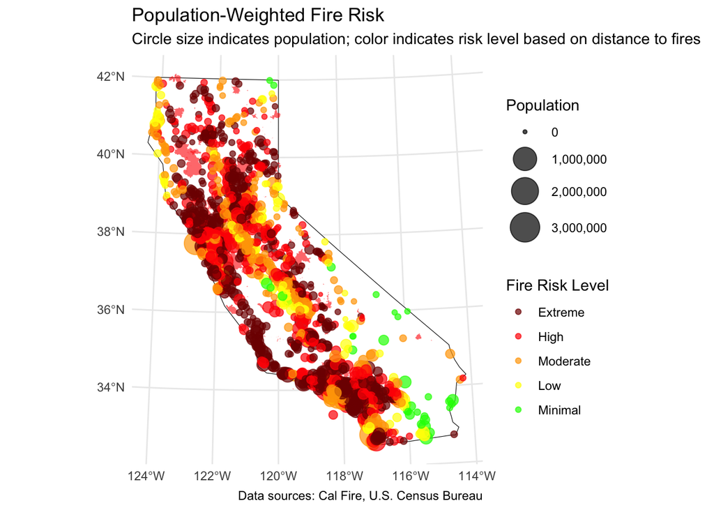

```r
# Visualize population-weighted fire risk
# Before creating the plot, convert risk_category to an ordered factor
places_ca_centroids_3310 <- places_ca_centroids_3310 %>%
  mutate(
    risk_category = factor(
      risk_category,
      levels = c("Extreme", "High", "Moderate", "Low", "Minimal"),
      ordered = TRUE
    )
  )
# Create a map showing cities with circle size proportional to population and color by risk
ggplot() +
  # California boundary
  geom_sf(data = CA_3310, fill = "white", color = "black") +

  # Fire polygons
  geom_sf(data = data_3310, fill = "red", alpha = 0.6, color = NA) +

  # City points with size based on population and color based on risk
  geom_sf(
    data = places_ca_centroids_3310 %>% filter(!is.na(Population)),
    aes(
      color = risk_category,
      size = Population
    ),
    alpha = 0.7
  ) +

  # Scale settings
  scale_color_manual(
    values = c("Extreme" = "#7F0000", "High" = "#FF0000",
               "Moderate" = "#FFA500", "Low" = "#FFFF00", "Minimal" = "#00FF00"),
    name = "Fire Risk Level"
  ) +
  scale_size_continuous(
  name = "Population",
  range = c(1, 10),  # Doubled the size range from (0.5, 5) to (1, 10)
  labels = scales::comma,
  trans = "sqrt"     # Using a square root transformation to help with readability
  ) +

  # Map styling
  theme_minimal() +
  labs(
    title = "Population-Weighted Fire Risk",
    subtitle = "Circle size indicates population; color indicates risk level based on distance to fires",
    caption = "Data sources: Cal Fire, U.S. Census Bureau"
  )
```

The map reveals a concerning pattern where many heavily populated areas (represented by larger circles) fall within extreme or high-risk zones (dark red and red colors).

What makes this visualization particularly valuable is how **it combines two critical factors - population size and proximity to fires** - to identify communities where the most people faced the highest danger. This approach highlights areas where emergency resources might have been most needed, rather than treating all locations within buffer zones equally. The prevalence of large circles in red and dark red zones suggests that a substantial portion of California’s population lived under significant wildfire threat during this period.

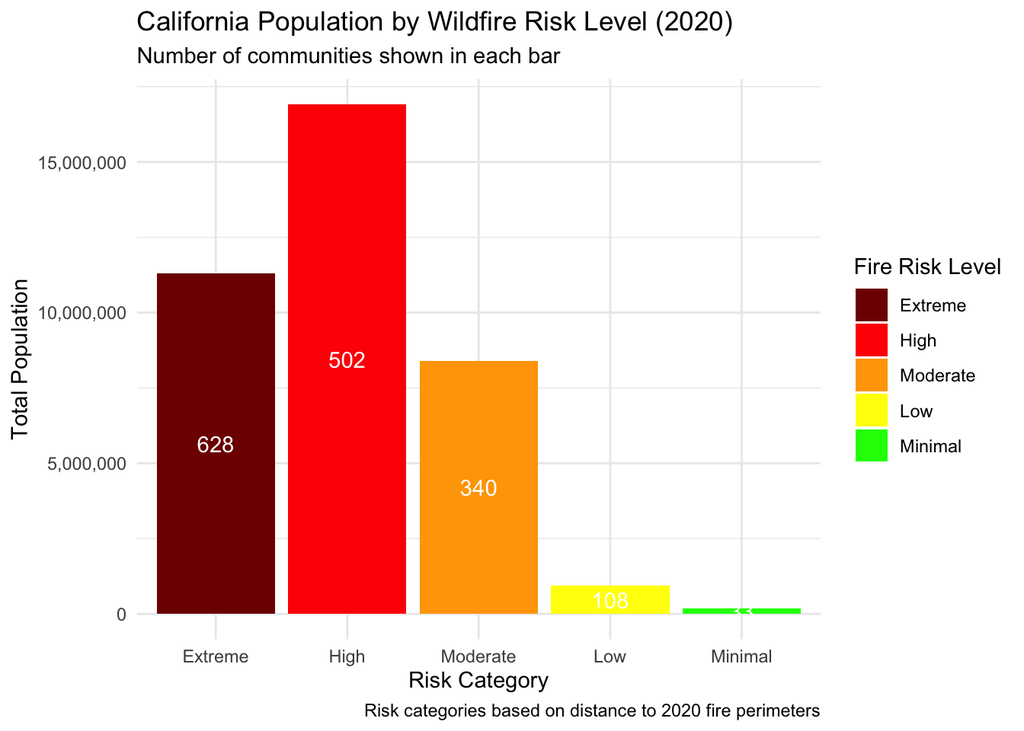

```r
# Summarize population at risk by risk category
risk_summary <- places_ca_centroids_3310 %>%
  st_drop_geometry() %>%
  group_by(risk_category) %>%
  summarize(
    total_population = sum(Population, na.rm = TRUE),
    cities_count = n()
  ) %>%
  arrange(factor(risk_category, levels = c("Extreme", "High", "Moderate", "Low", "Minimal")))

# Plot the summary
ggplot(risk_summary, aes(x = factor(risk_category,
                                    levels = c("Extreme", "High", "Moderate", "Low", "Minimal")),
                         y = total_population)) +
  geom_bar(stat = "identity", aes(fill = factor(risk_category))) +
  geom_text(aes(label = paste0(cities_count)),
            position = position_stack(vjust = 0.5), color = "white") +
  scale_fill_manual(
    values = c("Extreme" = "#7F0000", "High" = "#FF0000",
               "Moderate" = "#FFA500", "Low" = "#FFFF00", "Minimal" = "#00FF00"),
    name = "Fire Risk Level"
  ) +
  scale_y_continuous(labels = scales::comma) +
  theme_minimal() +
  labs(
    title = "California Population by Wildfire Risk Level (2020)",
    subtitle = "Number of communities shown in each bar",
    x = "Risk Category",
    y = "Total Population",
    caption = "Risk categories based on distance to 2020 fire perimeters"
  ) +
  theme(axis.text.x = element_text(angle = 0))
```

**Note that** “places” in TIGER/Line shapefiles extends well beyond just incorporated cities. The dataset includes:

- incorporated municipalities (cities, towns),
- Census Designated Places (CDPs) which are unincorporated communities with defined boundaries,
- various smaller settlements that have distinct geographic identities recognized by the Census Bureau

While California has 482 incorporated cities, it has over 1,000 additional Census Designated Places, bringing the total close to the number we’re seeing. This comprehensive inclusion actually strengthens our analysis by providing a more complete picture of population exposure to wildfire risk across all types of human settlements in California, not just major cities.

## 7.2 Land Cover Type Analysis

The second component examines the relationship between land cover types and fire perimeters, which helps illuminate:

- Fuel Availability: Different vegetation types (forests, shrublands, grasslands) have varying combustibility and fuel characteristics that influence fire behavior.
- Development Patterns: By distinguishing between natural and developed areas affected by fires, we can better understand the human-wildfire relationship in California.
- Ecological Impact Assessment: Identifying which ecosystem types were most affected provides insight into potential ecological consequences and recovery trajectories.

Using the National Land Cover Database (NLCD), our analysis categorizes and quantifies the types of land affected by the 2020 fires, with special attention to the distribution between developed (urban/populated) versus natural/other land covers.

```r
# NLCD and Fire Perimeter Data Processing

# Load NLCD raster
nlcd_raster <- rast("/Users/gretchenmoulton/Documents/GeoSpatial/Annual_NLCD_LndCov_2020_CU_C1V0.tif")

# Reproject CA boundary to match raster CRS
CA <- california_boundary %>%
  st_transform(crs(nlcd_raster))

# Convert California boundary to terra format and crop raster
nlcd_ca <- crop(nlcd_raster, vect(CA), mask = TRUE)
```

```
## |---------|---------|---------|---------|=========================================                                          |---------|---------|---------|---------|=========================================
```

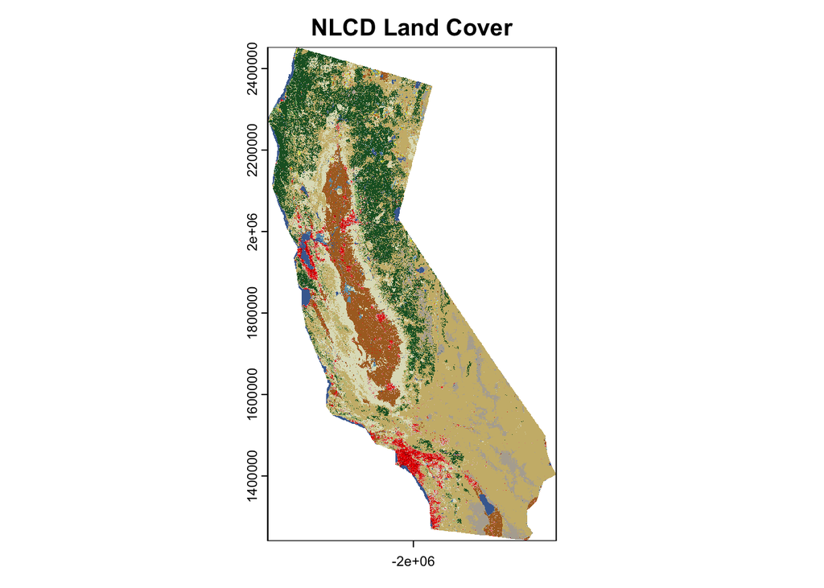

```r
# Visualize cropped raster
plot(nlcd_ca, main = "NLCD Land Cover")
```

```r
#Save cropped raster
writeRaster(nlcd_ca, "NLCD_2020_California.tif", overwrite = TRUE)
```

```
## |---------|---------|---------|---------|=========================================
```

```r
# Load California Land Cover Raster
nlcd_ca <- rast("/Users/gretchenmoulton/Documents/GeoSpatial/NLCD_2020_California.tif")

# Load and clean 2020 fire perimeters, ensuring CRS consistency
fire_perimeters <- st_read("/Users/gretchenmoulton/Documents/GeoSpatial/share_2/California_Fire_Perimeters_(all)/California_Fire_Perimeters_(all).shp") %>%
  filter(YEAR_ == 2020) %>%
  st_make_valid() %>%
  filter(!st_is_empty(.)) %>%
  st_transform(crs(nlcd_raster))
# Convert fire perimeters to terra vector format
fire_vect <- vect(fire_perimeters)

# Extract land cover data intersecting fires
landcover_fire_extract <- terra::extract(nlcd_ca, fire_vect)

# Convert extracted data to a dataframe and rename columns
landcover_fire_data <- data.frame(landcover_fire_extract)
colnames(landcover_fire_data) <- c("ID", "Land_Cover_Type")

# Summarize extracted land cover data
landcover_summary <- landcover_fire_data %>%
  group_by(Land_Cover_Type) %>%
  summarise(Count = n()) %>%
  arrange(desc(Count))

print(landcover_summary)
```

```
## # A tibble: 16 × 2
##    Land_Cover_Type   Count
##              <int>   <int>
##  1              52 6998187
##  2              42 6824835
##  3              71 3970934
##  4              NA  369912
##  5              43  345179
##  6              21  231006
##  7              41  104816
##  8              22   80187
##  9              90   47870
## 10              11   17731
## 11              95   16092
## 12              31   11987
## 13              82    9030
## 14              81    6181
## 15              23    5894
## 16              24     165
```

```r
# NLCD Raster Processing and Conversion

# Reduce raster resolution
nlcd_ca_resampled <- aggregate(nlcd_ca, fact=10, fun=modal)  # Increase `fact` if necessary

# Convert to dataframe
nlcd_df <- as.data.frame(nlcd_ca_resampled, xy = TRUE, cells = TRUE)
colnames(nlcd_df) <- c("x", "y", "Land_Cover_Type")

# Check raster categories before conversion
print(unique(values(nlcd_ca_resampled)))
```

```
##       Annual_NLCD_LndCov_2020_CU_C1V0
##  [1,]                              NA
##  [2,]                              22
##  [3,]                              43
##  [4,]                              11
##  [5,]                              81
##  [6,]                              42
##  [7,]                              41
##  [8,]                              52
##  [9,]                              71
## [10,]                              31
## [11,]                              21
## [12,]                              23
## [13,]                              90
## [14,]                              95
## [15,]                              82
## [16,]                              24
## [17,]                              12
```

```r
# Convert raster to polygon while preserving values
nlcd_poly <- as.polygons(nlcd_ca_resampled, dissolve = TRUE) %>%
  st_as_sf()

# Rename the raster value column (which currently has the raster filename)
colnames(nlcd_poly)[colnames(nlcd_poly) == "Annual_NLCD_LndCov_2020_CU_C1V0"] <- "Land_Cover_Type"

# Ensure column exists
if (!"Land_Cover_Type" %in% colnames(nlcd_poly)) {
  stop("Land_Cover_Type column is missing in nlcd_poly. Check raster attributes.")
}
```

```r
# Define land cover type labels correctly
land_cover_labels <- data.frame(
  Land_Cover_Type = c(11, 12, 21, 22, 23, 24, 31, 41, 42, 43, 52, 71, 81, 82, 90, 95),
  Land_Cover_Name = c("Open Water", "Perennial Ice/Snow", "Developed, Open Space",
                      "Developed, Low Intensity", "Developed, Medium Intensity",
                      "Developed, High Intensity", "Barren Land",
                      "Deciduous Forest", "Evergreen Forest", "Mixed Forest",
                      "Shrub/Scrub", "Grassland/Herbaceous", "Pasture/Hay",
                      "Cultivated Crops", "Woody Wetlands",
                      "Emergent Herbaceous Wetlands")
)
```